# Complex Analysis Qualifying Exam Review

> A great deal of content borrowed from the following: https://web.stanford.edu/~chriseur/notes_pdf/Eur_ComplexAnalysis_Notes.pdf

# 1 General Info / Tips / Techniques

## 1.1 Greatest Hits

Things to know well:

- Estimates for derivatives, mean value theorem
- Properties of linear fractional transformations
- Automorphisms of ${\mathbb{D}}, {\mathbb{C}}, {\mathbb{CP}}^1$.

## 1.2 Common Tricks

- Virtually any time: consider $1/f(z)$ and $f(1/z)$.
- Setting $w=e^z$ is useful.

If you want to show that a function $f$ is constant, try one of the following:

- Write $f = u + iv$ and use Cauchy-Riemann to show $u_x, u_y = 0$, etc.
- Show that $f$ is entire and bounded.
  - If you additionally want to show $f$ is zero, show $\lim_{z\to\infty} f(z) = 0$.

To show a function is holomorphic,

- Use Morera’s theorem
- Find a primitive (sufficient but not necessary)

To count zeros:

- Rouche’s theorem
- The argument principle

## 1.3 Basic but Useful Facts

### 1.3.1 Arithmetic

$$\begin{align*}
z\mkern 1.5mu\overline{\mkern-1.5muz\mkern-1.5mu}\mkern 1.5mu &= {\left\lvert {z} \right\rvert}^2 &&
\operatorname{Arg}(z/w) = \operatorname{Arg}(z) - \operatorname{Arg}(w) \\
\Re(z) &= { z + \mkern 1.5mu\overline{\mkern-1.5muz\mkern-1.5mu}\mkern 1.5mu \over 2} &&
\Im(z) = {z - \mkern 1.5mu\overline{\mkern-1.5muz\mkern-1.5mu}\mkern 1.5mu \over 2i}
.\end{align*}$$

Exponential forms of cosine and sine, where it’s sometimes useful to set $w\mathrel{\vcenter{:}}= e^{iz}$:
$$\begin{align*}
\cos(z)
&= \frac 1 2 \qty{e^{iz} + e^{-iz}} = {1\over 2}(w+ w^{-1})\\
\sin(z)
&= \frac{1}{2i}\qty{e^{iz} - e^{-iz}} = {1\over 2i}(w-w^{-1})
.\end{align*}$$

Exponential forms of *hyperbolic* cosine and sin:
$$\begin{align*}
\cosh(z)
&= \cos(iz)
= {1\over 2}\qty{e^z + e^{-z}} \\
\sinh(z)
&= -i \sin(iz)
= {1\over 2}\qty{e^z - e^{-z}}
.\end{align*}$$

Some other useful facts about the hyperbolic exponentials:

- They are periodic with period $2\pi i$.
- ${\frac{\partial }{\partial z}\,}\cosh(z) = \sinh(z)$ and ${\frac{\partial }{\partial z}\,}\sinh(z) = \cosh(z)$.
- $\sinh$ is odd and $\cosh$ is even.
- $\cosh(z + i\pi) = -\cosh(z)$ and $\sinh(z + i\pi) = -\sinh(z)$.
- $\cosh$ has zeros at $\left\{{i\pi\qty{2k+1\over 2}}\right\} = \left\{{i \qty{\pi/2 + k\pi}}\right\}$, i.e. $\cdots, -\pi/2, \pi/2, 3\pi/2,\cdots$, the half-integers.
- $\sinh$ has zeros at $\left\{{i\pi k}\right\}$, i.e. the integers.

Some computations that come up frequently:
$$\begin{align*}
{\left\lvert {z \pm w} \right\rvert}^2 &= {\left\lvert {z} \right\rvert}^2 + {\left\lvert {w} \right\rvert}^z + 2\Re(\mkern 1.5mu\overline{\mkern-1.5muw\mkern-1.5mu}\mkern 1.5muz) \\
(a+bi)(c+di) &= (ac - bd) + (ad + bc) \\
{1\over {\left\lvert {a+b} \right\rvert}} &\leq {1 \over {{\left\lvert {a} \right\rvert} - {\left\lvert {b} \right\rvert}}} &&
{\left\lvert {e^{z}} \right\rvert} = e^{\Re(z)}, \quad \arg(e^z) = \Im(z)
.\end{align*}$$

### 1.3.2 Calculus

Various differentials:
$$\begin{align*}
dz &= dx + i~dy \\
d\mkern 1.5mu\overline{\mkern-1.5muz\mkern-1.5mu}\mkern 1.5mu &= dx - i~dy \\ \\
f_z &= f_x = f_y / i
.\end{align*}$$

Integral of a complex exponential:
$$\begin{align*}
\int_{0}^{2 \pi} e^{i \ell x} d x
&=\left\{\begin{array}{ll}
{2 \pi} & {\ell=0} \\
{0} & \text{else}
\end{array}\right.
.\end{align*}$$

## 1.4 Series

Define $(n)_k$ to be the falling factorial
$$\begin{align*}
\prod_{j=0}^{k-1} (n-k) = n(n-1)\cdots(n-k+1)
\end{align*}
and set \({n\choose k} \mathrel{\vcenter{:}}=(n)_k/k!\), then
\begin{align*}
(x+y)^n = \sum_{k\geq 0} {n\choose k} x^{k}y^{n-k}
.\end{align*}$$

$$\begin{align*}
\sum_{k=1}^{n} k
&=\frac{n(n+1)}{2} \\
\sum_{k=1}^{n} k^{2}
&=\frac{n(n+1)(2 n+1)}{6} \\
\sum_{k=1}^{n} k^{3}
&=\frac{n^{2}(n+1)^{2}}{4} \\
\sum_{0\leq k \leq N} z^k
&= {1 - z^{N+1} \over 1-z} \\
{1\over 1-z} &= \sum_{k\geq 0} z^k \\
e^z &= \sum_{k\geq 0} {z^k \over k!} \\
\sin(z)
&= \sum_{\substack{ k \geq 1 \\ \text{odd} }} (-1)^{k+1 \over 2} {z^k \over k!} \\
&= z - {1\over 3!}z^3 + {1\over 5!}z^5 + \cdots \\
\cos(z)
&= \sum_{\substack{ k \geq 0 \\ \text{even}} } (-1)^{k\over 2} {z^k \over k!} \\
&= 1 - {1\over 2!}z^2 + {1\over 4!}z^4 + \cdots \\
\\
\cosh(z) &= \sum_{k\geq 0} { z^{2k} \over (2k)! } \\
\sinh(z) &= \sum_{k\geq 0} { z^{2k+1} \over (2k+1)! } \\
\log(1-x)
&= \sum_{k \geq 0} {z^k\over k} \quad {\left\lvert {z} \right\rvert} < 1 \\
{\frac{\partial }{\partial z}\,} \sum_{k=0}^\infty a_k z^k
&= \sum_{k=0}^\infty a_{k+1}z^k \\
(1+x)^{1/2}
&= 1 + (1/2)x + {(1/2)(-1/2) \over 2!}x^2 + {(1/2)(-1/2)(-3/2) \over 3!}x^3 + \cdots \\
&= 1 + {1\over 2} x - {1\over 8}x^2 + {1\over 16}x^3 - \cdots
\end{align*}$$

Useful trick for expanding square roots:
$$\begin{align*}
\sqrt{z} = \sqrt{z_0 + z - z_0} = \sqrt{z_0 \qty{ 1 + {z-z_0 \over z} }} = \sqrt{z_0} \sqrt{1+u},\quad u\mathrel{\vcenter{:}}={z-z_0 \over z} \\
\implies \sqrt{z} = \sqrt{z_0} \sum_{k\geq 0} {1/2 \choose k} \qty{z- z_0 \over z}^k
.\end{align*}$$

# 2 Calculus Preliminaries

## 2.1 Definitions

A sequence of functions $f_n$ is said to converge **locally uniformly** on $\Omega \subseteq {\mathbb{C}}$ iff $f_n\to f$ uniformly on every compact subset $K \subseteq \Omega$.

A family of functions $f_n$ is **equicontinuous** iff for every ${\varepsilon}$ there exists a $\delta = \delta({\varepsilon})$ (not depending on $n$ or $f_n$) such that ${\left\lvert {x-y} \right\rvert}<{\varepsilon}\implies {\left\lvert {f_n(x) - f_n(y)} \right\rvert} < {\varepsilon}$ for all $n$.

Recall Arzelà-Ascoli, an analog of Heine-Borel: for $X$ compact Hausdorff, consider the the Banach space $C(X; {\mathbb{R}})$ equipped with the *uniform norm* ${\left\lVert {f} \right\rVert}_{\infty, X} \mathrel{\vcenter{:}}=\sup_{x\in X} {\left\lvert {f(x)} \right\rvert}$. Then a subset $A \subseteq X$ is compact iff $A$ is closed, uniformly bounded, and equicontinuous. As a consequence, if $A$ is a sequence, it contains a subsequence converging uniformly to a continuous function. The proof is an ${\varepsilon}/3$ argument.

A continuous function on a compact set is uniformly continuous.

A function $f\in \mathop{\mathrm{Hol}}(U; {\mathbb{C}})$ is called **univalent** if $f$ is injective.

If $f: \Omega \to \Omega'$ is a univalent surjection, $f$ is invertible on $\Omega$ and $f^{-1}$ is holomorphic. Compare to real functions: $f(x) = x^3$ is injective on $(-c, c)$ for any $c$ but $f'(0) = 0$ and $f^{-1}(x) \mathrel{\vcenter{:}}= x^{1/3}$ is not differentiable at zero.

## 2.2 Theorems

For $f \in C^1({\mathbb{R}}; {\mathbb{R}})$ with $f'(a) \neq 0$, then $f$ is invertible in a neighborhood $U \ni a$, $g\mathrel{\vcenter{:}}= f^{-1}\in C^1(U; {\mathbb{R}})$, and at $b\mathrel{\vcenter{:}}= f(a)$ the derivative of $g$ is given by
$$\begin{align*}
g'(b) = {1 \over f'(a)}
.\end{align*}
For \(F \in C^1({\mathbb{R}}^n, {\mathbb{R}}^n)\) with \(D_f\) invertible in a neighborhood of \(a\), so \(\operatorname{det}(J_f)\neq 0\), then setting \(b\mathrel{\vcenter{:}}= F(a)\),
\begin{align*}
J_{F^{-1}}(q) = \qty{J_F(p)}^{-1}
.\end{align*}$$

The version for holomorphic functions: if $f\in \mathop{\mathrm{Hol}}({\mathbb{C}}; {\mathbb{C}})$ with $f'(p)\neq 0$ then there is a neighborhood $V\ni p$ with that $f\in \mathop{\mathrm{BiHol}}(V, f(V))$.

If $\Omega \subseteq {\mathbb{C}}$ is bounded with ${{\partial}}\Omega$ piecewise smooth and $f, g\in C^1(\mkern 1.5mu\overline{\mkern-1.5mu\Omega\mkern-1.5mu}\mkern 1.5mu)$, then
$$\begin{align*}\int_{{{\partial}}\Omega} f\, dx + g\, dy = \iint_{\Omega} \qty{ {\frac{\partial g}{\partial x}\,} - {\frac{\partial f}{\partial y}\,} } \, \,dA.\end{align*}
In vector form,
\begin{align*}
\int_\gamma F\cdot \,dr= \iint_R \operatorname{curl}F \,dA
.\end{align*}$$

## 2.3 Convergence

Recall that absolutely convergent implies convergent, but not conversely: $\sum k^{-1}= \infty$ but $\sum (-1)^k k^{-1}< \infty$. This converges because the even (odd) partial sums are monotone increasing/decreasing respectively and in $(0, 1)$, so they converge to a finite number. Their difference converges to 0, and their common limit is the limit of the sum.

A series of functions $\sum_{n=1}^\infty f_n(x)$ converges uniformly iff
$$\begin{align*}
\lim_{n\to \infty} {\left\lVert { \sum_{k\geq n} f_k } \right\rVert}_\infty = 0
.\end{align*}$$

If $\left\{{f_n}\right\}$ with $f_n: \Omega \to {\mathbb{C}}$ and there exists a sequence $\left\{{M_n}\right\}$ with ${\left\lVert {f_n} \right\rVert}_\infty \leq M_n$ and $\sum_{n\in {\mathbb{N}}} M_n < \infty$, then $f(x) \mathrel{\vcenter{:}}=\sum_{n\in {\mathbb{N}}} f_n(x)$ converges absolutely and uniformly on $\Omega$. Moreover, if the $f_n$ are continuous, by the uniform limit theorem, $f$ is again continuous.

## 2.4 Integrals

Some basic facts needed for line integrals in the plane:

- $\operatorname{grad}f = {\left[ { {\frac{\partial f}{\partial x}\,}, {\frac{\partial f}{\partial y}\,} } \right]}$.
  - If $F = \operatorname{grad}f$ for some $f$, $F$ is a vector field.
- Given $f(x, y)$ and $\gamma(t)$, the chain rule yields ${\frac{\partial }{\partial t}\,} (f\circ \gamma)(t) = {\left\langle { \operatorname{grad}f\circ \gamma)(t)},~{\gamma'(t)} \right\rangle}$.
- For $F(x, y) = {\left[ {M(x, y), N(x, y)} \right]}$, $\operatorname{curl}F = {\frac{\partial N}{\partial x}\,} - {\frac{\partial M}{\partial y}\,}$ and $\operatorname{Div}F = {\frac{\partial M}{\partial x}\,} + {\frac{\partial N}{\partial y}\,}$.
- $\int_\gamma F\cdot \,dr= \int_a^b F(\gamma(t))\cdot \gamma'(t) \,dt$.

## 2.5 Series and Sequences

Note that if a power series converges uniformly, then summing commutes with integrating or differentiating.

Consider $\sum c_k z^k$, set $R = \lim {\left\lvert {c_{k+1} \over c_k} \right\rvert}$, and recall the **ratio test**:

- $R\in (0, 1) \implies$ convergence.
- $R\in (1, \infty] \implies$ divergence.
- $R=1$ yields no information.

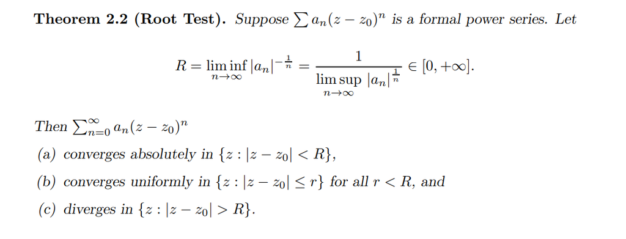

For $f(z) = \sum_{k\in {\mathbb{N}}} c_k z^k$, defining
$$\begin{align*}
{1\over R} \mathrel{\vcenter{:}}=\limsup_{k} {\left\lvert {a_k} \right\rvert}^{1\over k}
,\end{align*}
then \(f\) converges absolutely and uniformly for \(D_R \mathrel{\vcenter{:}}={\left\lvert {z} \right\rvert} < R\) and diverges for \({\left\lvert {z} \right\rvert} > R\). Moreover \(f\) is holomorphic in \(D_R\), can be differentiated term-by-term, and \(f' = \sum_{k\in {\mathbb{N}}} n c_k z^k\).$$

Recall the **$p{\hbox{-}}$test**:
$$\begin{align*}
\sum n^{-p} < \infty \iff p \in (1, \infty)
.\end{align*}$$

The product of two sequences is given by the Cauchy product
$$\begin{align*}
\sum a_kz^k \cdot \sum b_k z^k = \sum c_k z^k,\quad c_k \mathrel{\vcenter{:}}=\sum_{j\leq k} a_k b_{k-j}
.\end{align*}$$

Recall how to carry out polynomial long division:

- For every root $r_i$ of multiplicity 1, include a term $A/(x-r_i)$.
- For any factors $g(x)$ of multiplicity $k$, include terms $A_1/g(x), A_2/g(x)^2, \cdots, A_k / g(x)^k$.
- For irreducible quadratic factors $h_i(x)$, include terms of the form ${Ax+B \over h_i(x)}$.

## 2.6 Exercises

Find the radius of convergences for the power series expansion of $\sqrt{z}$ about $z_0 = 4 +3i$.

# 3 Preliminaries

A closed Jordan curve that separates ${\mathbb{C}}$ into an exterior and interior region is referred to as a **toy contour**.

The complex $n$th roots of $z \mathrel{\vcenter{:}}= r e^{i\theta}$ are given by
$$\begin{align*}
\left\{{ \omega_k \mathrel{\vcenter{:}}= r^{1/n} e^{i \qty{ \theta + 2k\pi \over n} } {~\mathrel{\Big|}~}0 \leq k \leq n-1 }\right\}
.\end{align*}
Note that one root is \(r^{1/n}\in {\mathbb{R}}\), and the rest are separated by angles of \(2\pi/n\). Mnemonic:
\begin{align*}
z = re^{i\theta} = re^{i\qty{\theta + 2k\pi}} \implies z^{1/n} = \cdots
.\end{align*}$$

## 3.1 Complex Log

For $z= r e^{i\theta}\neq 0$, $\theta$ is of the form $\Theta + 2k\pi$ where $\Theta = \operatorname{Arg}z$ We define
$$\begin{align*}
\log(z) = \ln\qty{{\left\lvert {z} \right\rvert}} + i\operatorname{Arg}(z)
\end{align*}
and \(z^c \mathrel{\vcenter{:}}= e^{c\log(z)}\). Thus
\begin{align*}
\log(re^{i\theta}) = \ln {\left\lvert {r} \right\rvert} + i\theta
.\end{align*}$$

Common trick:
$$\begin{align*}
f^{1/n} = e^{{1\over n} \log(f)}
,\end{align*}
taking (say) a principal branch of \(\log\) given by \({\mathbb{C}}\setminus(-\infty, 0] \times 0\).$$

Suppose $\Omega$ is a simply-connected region such that $1\in \Omega, 0\not\in\Omega$. Then there exists a branch of $F(z) \mathrel{\vcenter{:}}=\operatorname{Log}(z)$ such that

- $F$ is holomorphic on $\Omega$,
- $e^{F(z)} = z$ for all $z\in \Omega$
- $F(x) = \log(x)$ for $x\in {\mathbb{R}}$ in a neighborhood of $1$.

Take ${\mathbb{C}}$ and delete ${\mathbb{R}}^{\leq 0}$ to obtain the **principal branch** of the logarithm. Equivalently, this is define for all $z=re^{i\theta}$ where $\theta \in (-\pi, \pi)$.

Here the log is defined as
$$\begin{align*}
\operatorname{Log}(z) \mathrel{\vcenter{:}}=\log(r) + i\theta && {\left\lvert {\theta} \right\rvert} < \pi
.\end{align*}
Similarly define
\begin{align*}
z^{\alpha} \mathrel{\vcenter{:}}= e^{\alpha \operatorname{Log}(z)}
.\end{align*}$$

It’s tempting to define
$$\begin{align*}
z^{1\over n} \mathrel{\vcenter{:}}=(re^{i\theta})^{1\over n} = r^{1\over n} e^{i\theta \over n}
,\end{align*}
but this requires a branch cut to ensure continuity.$$

Note the problem: for $z\mathrel{\vcenter{:}}= x+i0 \in {\mathbb{R}}^{\leq 0}$, just above the axis consider $z_+ \mathrel{\vcenter{:}}= x + i{\varepsilon}$ and $z_- \mathrel{\vcenter{:}}= x-i{\varepsilon}$. Then

- $\log(z_+) = \log{\left\lvert {x} \right\rvert} + i\pi$, and
- $\log(z_-) = \log{\left\lvert {x} \right\rvert} - i\pi$.

So $\log$ can’t even be made continuous if one crosses the branch. The issue is the **branch point** or **branch singularity** at $z=0$.

If $f$ is holomorphic and nonvanishing on a simply-connected region $\Omega$, then there exists a holomorphic $G$ on $\Omega$ such that
$$\begin{align*}
f(z) = e^{G(z)}
.\end{align*}$$

## 3.2 Complex Calculus

When parameterizing integrals $\int_\gamma f(z)\,dz$, parameterize $\gamma$ by $\theta$ and write $z=re^{i\theta}$ so $\,dz= ire^{i\theta}\,d\theta$.

$f(z) = \sin(z), \cos(z)$ are unbounded on ${\mathbb{C}}$! An easy way to see this: they are nonconstant and entire, thus unbounded by Liouville.

You can show $f(z) = \sqrt{z}$ is not holomorphic by showing its integral over $S^1$ is nonzero. This is a direct computation:
$$\begin{align*}
\int_{S^1} z^{1/2} \,dz
&= \int_0^{2\pi} (e^{i\theta})^{1/2} ie^{i\theta} \,d\theta\\
&= i \int_0^{2\pi} e^{i3\theta \over 2}\,d\theta\\
&= i \qty{2\over 3i} e^{i3\theta \over 2}\Big|_{0}^{2\pi} \\
&= {2\over 3}\qty{e^{3\pi i - 1}} \\
&= -{4\over 3}
.\end{align*}$$

Note an issue: a different parameterization yields a different (still nonzero) number
$$\begin{align*}
\cdots
&= \int_{-\pi}^{\pi} (e^{i\theta})^{1/2} ie^{i\theta} \,d\theta\\
&= {2\over 3}\qty{ e^{3\pi i \over 2} - e^{-3\pi i \over 2}} \\
&= -{4i\over 3}
.\end{align*}
This is these are paths that don’t lift to closed loops on the Riemann surface defined by \(z\mapsto z^2\).$$

### 3.2.1 Holomorphy and Cauchy-Riemann

A function $f:\Omega \to {\mathbb{C}}$ is *analytic* at $z_0\in \Omega$ iff there exists a power series $g(z) = \sum a_n (z-z_0)^n$ with radius of convergence $R>0$ and a neighborhood $U\ni z_0$ such that $f(z) = g(z)$ on $U$.

A function $f: {\mathbb{C}}\to {\mathbb{C}}$ is **complex differentiable** or **holomorphic** at $z_0$ iff the following limit exists:
$$\begin{align*}
\lim_{h\to 0} { f(z_0 + h) - f(h) \over h }
.\end{align*}
A function that is holomorphic on \({\mathbb{C}}\) is said to be entire.$$

Equivalently, there exists an $\alpha\in {\mathbb{C}}$ such that
$$\begin{align*}
f(z_0+h) - f(z_0) = \alpha h + R(h) && R(h) \overset{h\to 0}\longrightarrow 0
.\end{align*}
In this case, \(\alpha = f'(z_0)\).$$

- $f(z) \mathrel{\vcenter{:}}={\left\lvert {z} \right\rvert}$ is not holomorphic.
- $f(z) \mathrel{\vcenter{:}}=\arg{z}$ is not holomorphic.
- $f(z) \mathrel{\vcenter{:}}=\Re{z}$ is not holomorphic.
- $f(z) \mathrel{\vcenter{:}}=\Im{z}$ is not holomorphic.
- $f(z) = {1\over z}$ is holomorphic on ${\mathbb{C}}\setminus\left\{{0}\right\}$ but not holomorphic on ${\mathbb{C}}$
- $f(z) = \mkern 1.5mu\overline{\mkern-1.5muz\mkern-1.5mu}\mkern 1.5mu$ is *not* holomorphic, but is real differentiable:
  $$\begin{align*}
  {f(z_0 + h) - f(z_0) \over h } = {\mkern 1.5mu\overline{\mkern-1.5muz_0\mkern-1.5mu}\mkern 1.5mu + \mkern 1.5mu\overline{\mkern-1.5muh\mkern-1.5mu}\mkern 1.5mu - \mkern 1.5mu\overline{\mkern-1.5muz_0\mkern-1.5mu}\mkern 1.5mu \over h} = {\mkern 1.5mu\overline{\mkern-1.5muh\mkern-1.5mu}\mkern 1.5mu \over h} = {re^{-i\theta} \over re^{i\theta}} = e^{-2i\theta} \overset{h\to 0}\longrightarrow e^{-2i\theta}
  ,\end{align*}
  which is a complex number that depends on \(\theta\) and is thus not a single value.$$

A function $F: {\mathbb{R}}^n\to {\mathbb{R}}^m$ is **real-differentiable** at $\mathbf{p}$ iff there exists a linear transformation $A$ such that
$$\begin{align*}
{ {\left\lVert { F(\mathbf{p} + \mathbf{h}) - F(\mathbf{p}) - A(\mathbf{h}) } \right\rVert} \over {\left\lVert { \mathbf{h} } \right\rVert} } \overset{{\left\lVert {\mathbf{h}} \right\rVert}\to 0}\longrightarrow 0
.\end{align*}
Rewriting,
\begin{align*}
{\left\lVert { F(\mathbf{p} + \mathbf{h}) - F(\mathbf{p}) - A(\mathbf{h}) } \right\rVert} = {\left\lVert { \mathbf{h} } \right\rVert} {\left\lVert { R(\mathbf{h}) } \right\rVert}
&& {\left\lVert {R(\mathbf{h}) } \right\rVert}\overset{{\left\lVert {\mathbf{h} } \right\rVert} \to 0}\longrightarrow 0
.\end{align*}$$

Equivalently,
$$\begin{align*}
F(\mathbf{p} + \mathbf{h}) - F(\mathbf{p}) = A(\mathbf{h}) + {\left\lVert {\mathbf{h}} \right\rVert} R(\mathbf{h}) && {\left\lVert {R(\mathbf{h}) } \right\rVert}\overset{{\left\lVert {\mathbf{h} } \right\rVert} \to 0}\longrightarrow 0
.\end{align*}$$

Or in a slightly more useful form,
$$\begin{align*}
F(\mathbf{p} + \mathbf{h}) = F(\mathbf{p}) + A(\mathbf{h}) + R(\mathbf{h}) && R\in o( {\left\lVert {\mathbf{h}} \right\rVert}), \text{ i.e. }
{ {\left\lVert { R(\mathbf{h}) } \right\rVert} \over {\left\lVert {\mathbf{h}} \right\rVert}} \overset{\mathbf{h}\to 0}\longrightarrow 0
.\end{align*}$$

If $f$ is differentiable at $z_0$, then the limit defining $f'(z_0)$ must exist when approaching from any direction. Identify $f(z) = f(x, y)$ and write $z_0 = x+ iy$, then first consider $h\in RR$, so $h = h_1 + ih_2$ with $h_2 = 0$. Then
$$\begin{align*}
f'(z_0) =
\lim_{h_1\to 0} { f(x+h_1, y) - f(x, y) \over h_1}
\mathrel{\vcenter{:}}={\frac{\partial f}{\partial x}\,}(x, y)
.\end{align*}
Taking \(h \in i{\mathbb{R}}\) purely imaginary, so \(h= ih_2\),
\begin{align*}
f'(z_0)
= \lim_{ih_2\to 0} { f(x, y+h_2) - f(x, y) \over ih_2 } \mathrel{\vcenter{:}}={1\over i} {\frac{\partial f}{\partial y}\,}(x, y)
.\end{align*}
Equating,
\begin{align*}
{\frac{\partial f}{\partial x}\,} = {1\over i} {\frac{\partial f}{\partial y}\,}
,\end{align*}
and writing \(f = u + iv\) and \(1/i = -i\) yields
\begin{align*}
{\frac{\partial f}{\partial x}\,} &= {\frac{\partial u}{\partial x}\,} + i {\frac{\partial v}{\partial x}\,} \\
{1\over i} {\frac{\partial f}{\partial y}\,} &= {1\over i} \qty{ {\frac{\partial u}{\partial y}\,} + i {\frac{\partial v}{\partial y}\,}} = {\frac{\partial v}{\partial y}\,} - i{\frac{\partial u}{\partial y}\,}
.\end{align*}
Thus
\begin{align*}
{\frac{\partial u}{\partial x}\,} = {\frac{\partial v}{\partial y}\,} \hspace{8em} {\frac{\partial u}{\partial y}\,} = -{\frac{\partial v}{\partial x}\,}
.\end{align*}$$

$$\begin{align*}
\frac{\partial u}{\partial r}=\frac{1}{r} \frac{\partial v}{\partial \theta} \quad \text { and } \quad \frac{1}{r} \frac{\partial u}{\partial \theta}=-\frac{\partial v}{\partial r}
.\end{align*}$$

**(Click to expand proof)**

Setting
$$\begin{align*}
z = re^{i\theta} = r(\cos(\theta) + i\sin(\theta) ) = x+iy
\end{align*}
yields \(x=r\cos(\theta), y=r\sin(\theta)\), one can identify
\begin{align*}
x_r = \cos(\theta)&, x_\theta = -r\sin(\theta) \\
y_r = \sin(\theta)&, y_\theta = r\cos(\theta)
.\end{align*}$$

Now apply the chain rule:
$$\begin{align*}
u_r
&= u_x x_r + u_y y_r \\
&= v_y x_r -v_x y_r && \text{CR}\\
&= v_y \cos(\theta) - v_x \sin(\theta) \\
&= {1\over r}\qty{ v_y r\cos(\theta) - v_x r\sin(\theta) } \\
&= {1\over r}\qty { v_y y_\theta + v_x x_\theta} \\
&= {1\over r} v_\theta
.\end{align*}
Similarly,
\begin{align*}
v_r
&= v_x x_r + v_y y_r \\
&= v_x \cos(\theta) + v_y\sin(\theta) \\
&= -u_y\cos(\theta) + u_x\sin(\theta) && \text{CR} \\
&= {1\over r}\qty{ -u_y r\cos(\theta) + u_x r\sin(\theta)} \\
&= {1\over r}\qty{ -u_y y_\theta - u_x x_0 } \\
&= -{1\over r} u_\theta
.\end{align*}$$

Thus
$$\begin{align*}
\frac{\partial u}{\partial r}=\frac{1}{r} \frac{\partial v}{\partial \theta} \quad \text { and } \quad \frac{\partial v}{\partial r}=-\frac{1}{r} \frac{\partial u}{\partial \theta} \\
.\end{align*}$$

$f$ is holomorphic at $z_0$ iff there exists an $a\in {\mathbb{C}}$ such that
$$\begin{align*}
f(z_0 + h) - f(z_0) - ah = h \psi(h), \quad \psi(h) \overset{h\to 0}\to 0
.\end{align*}
In this case, \(a = f'(z_0)\).$$

### 3.2.2 Delbar and the Laplacian

$$\begin{align*}
{\partial}\mathrel{\vcenter{:}}={\partial}_z \mathrel{\vcenter{:}}={1\over 2}\qty{{\partial}_x - i {\partial}_y}
\quad
\text{ and }
\quad
{ \mkern 1.5mu\overline{\mkern-1.5mu{\partial}\mkern-1.5mu}\mkern 1.5mu}
\mathrel{\vcenter{:}}={\partial}_{\mkern 1.5mu\overline{\mkern-1.5muz\mkern-1.5mu}\mkern 1.5mu}
={1\over 2}\qty{ {\partial}_x + i{\partial}_y}
.\end{align*}
Moreover, \(f' = {\partial}f + { \mkern 1.5mu\overline{\mkern-1.5mu{\partial}\mkern-1.5mu}\mkern 1.5mu}f\).$$

$f$ is holomorphic at $z_0$ iff ${ \mkern 1.5mu\overline{\mkern-1.5mu{\partial}\mkern-1.5mu}\mkern 1.5mu}f(z_0) = 0$:
$$\begin{align*}
2{ \mkern 1.5mu\overline{\mkern-1.5mu{\partial}\mkern-1.5mu}\mkern 1.5mu}f
&\mathrel{\vcenter{:}}=({\partial}_x + i {\partial}_y) (u+iv) \\
&= u_x + iv_x + iu_y - v_y \\
&= (u_x - v_y) + i(u_y + v_x) \\
&= 0 && \text{by Cauchy-Riemann}
.\end{align*}$$

### 3.2.3 Harmonic Functions and the Laplacian

A real function of two variables $u(x, y)$ is **harmonic** iff it is in the kernel of the Laplacian operator:
$$\begin{align*}
\Delta u \mathrel{\vcenter{:}}=\qty{{\frac{\partial ^2}{\partial x^2}\,} + {\frac{\partial ^2}{\partial y^2}\,}}u = 0
.\end{align*}$$

If $f = u+iv$ with $u, v\in C^1({\mathbb{R}})$ satisfying the Cauchy-Riemann equations on $\Omega$, then $f$ is holomorphic on $\Omega$ and
$$\begin{align*}
f'(z) = {\partial}f = {1\over 2}\qty{u_x + iv_x}
.\end{align*}$$

If $f(z) = u(x, y) + iv(x, y)$ is holomorphic, then $u, v$ are harmonic.

**(Click to expand proof)**

- By CR,
  $$\begin{align*}
  u_x = v_y && u_y = -v_x
  .\end{align*}$$
- Differentiate with respect to $x$:
  $$\begin{align*}
  u_{xx} = v_{yx} && u_{yx} = -v_{xx}
  .\end{align*}$$
- Differentiate with respect to $y$:
  $$\begin{align*}
  u_{xy} = v_{yy} && u_{yy} = -v_{xy}
  .\end{align*}$$
- Clairaut’s theorem: partials are equal, so
  $$\begin{align*}
  u_{xx} - v_{yx} = 0 \implies u_{xx} + u_{yy} = 0 \\ \\
  v_{xx} + u_{yx} = 0 \implies v_{xx} + v_{yy} = 0 \\ \\
  .\end{align*}$$

### 3.2.4 Exercises

If $z_0$ is a zero of $f'$ of order $n$, then $f$ is $(n+1)$-to-one in a neighborhood of $z_0$.

Show that if $f' = 0$ on a domain $\Omega$, then $f$ is constant on $\Omega$

**(Click to expand solution)**

Write $f = u + iv$, then $0 = 2 f' = u_x + iv_x = u_y - iu_y$, so $\operatorname{grad}u = \operatorname{grad}v = 0$. Show $f$ is constant along every straight line segment $L$ by computing the directional derivative $\operatorname{grad}u \cdot \mathbf{v} = 0$ along $L$ connecting $p, q$. Then $u(p) = u(q) = a$ some constant, and $v(p) = v(q) = b$, so $f(z) = a+bi$ everywhere.

Show that if $f$ and $\mkern 1.5mu\overline{\mkern-1.5muf\mkern-1.5mu}\mkern 1.5mu$ are both holomorphic on a domain $\Omega$, then $f$ is constant on $\Omega$.

**(Click to expand solution)**

- Strategy: show $f'=0$.
- Write $f = u + iv$. Since $f$ is analytic, it satisfies CR, so
  $$\begin{align*}
  u_x = v_y && u_y = -v_x
  .\end{align*}$$
- Similarly write $\mkern 1.5mu\overline{\mkern-1.5muf\mkern-1.5mu}\mkern 1.5mu = U + iV$ where $U = u$ and $V = -v$. Since $\mkern 1.5mu\overline{\mkern-1.5muf\mkern-1.5mu}\mkern 1.5mu$ is analytic, it also satisfies CR , so
  $$\begin{align*}
  U_x = V_y && U_y = -V_x \\ \\
  \implies u_x = -v_y && u_y = v_x
  .\end{align*}$$
- Add the LHS of these two equations to get $2u_x = 0 \implies u_x = 0$. Subtract the right-hand side to get $-2v_x = 0 \implies v_x = 0$
- Since $f$ is analytic, it is holomorphic, so $f'$ exists and satisfies $f' = u_x + iv_x$. But by above, this is zero.
- By the previous exercise, $f'=0 \implies f$ is constant.

If $f$ is holomorphic on $\Omega$ and any of the following hold, then $f$ is constant:

1. $\Re(f)$ is constant.
2. $\Im(f)$ is constant.
3. ${\left\lvert {f} \right\rvert}$ is constant.

**(Click to expand solution)**

**Part 3**:

- Write ${\left\lvert {f} \right\rvert} = c \in {\mathbb{R}}$.
- If $c=0$, done, so suppose $c>0$.
- Use $f\mkern 1.5mu\overline{\mkern-1.5muf\mkern-1.5mu}\mkern 1.5mu = {\left\lvert {f} \right\rvert}^2 = c^2$ to write $\mkern 1.5mu\overline{\mkern-1.5muf\mkern-1.5mu}\mkern 1.5mu=c^2/f$.
- Since ${\left\lvert {f(z)} \right\rvert} = 0 \iff f(z) = 0$, we have $f\neq 0$ on $\Omega$, so $\mkern 1.5mu\overline{\mkern-1.5muf\mkern-1.5mu}\mkern 1.5mu$ is analytic.
- Similarly $f$ is analytic, and $f,\mkern 1.5mu\overline{\mkern-1.5muf\mkern-1.5mu}\mkern 1.5mu$ analytic implies $f'=0$ implies $f$ is constant.

## 3.3 Power Series

If $f$ is holomorphic on a region $\Omega$ with $\overline{ D_R(z_0)} \subseteq \Omega$, and for every $z\in D_r(z_0)$, $f$ has a power series expansion of the following form:
$$\begin{align*}
f(z)=\sum_{n=0}^{\infty} a_{n}\left(z-z_{0}\right)^{n} \quad\text{ where } a_{n}=\frac{f^{(n)}\left(z_{0}\right)}{n !}
= {1 \over 2\pi r^n}\int_0^{2\pi} f(z_0 + re^{i\theta})e^{-in\theta} \,d\theta
.\end{align*}$$

Any power series is smooth (and thus holomorphic) on its disc of convergence, and its derivatives can be obtained using term-by-term differentiation:
$$\begin{align*}
{\frac{\partial }{\partial z}\,} f(z) = {\frac{\partial }{\partial z}\,} \sum_{k\geq 0} c_k (z-z_0)^k = \sum_{k\geq 1} kc_k (z-z_0)^k
.\end{align*}
Moreover, the coefficients are given by
\begin{align*}
c_k = {f^{(n)}(z_0) \over n! }
.\end{align*}$$

By an application of the Cauchy integral formula (see S&S 7.1) if $f$ is holomorphic on $D_R(z_0)$ there is a formula for all $k\geq 0$ and all $0<r<R$:
$$\begin{align*}
c_k = {1\over 2\pi r^k} \int_0^{2\pi} f(z_0 + re^{i\theta}) e^{-in\theta}\,d\theta
.\end{align*}$$

$f(z) = e^z$ is uniformly convergent in any disc in ${\mathbb{C}}$.

**(Click to expand proof)**

Apply the estimate
$$\begin{align*}
{\left\lvert {e^z} \right\rvert} \leq \sum {{\left\lvert {z} \right\rvert}^n \over n!} = e^{{\left\lvert {z} \right\rvert}}
.\end{align*}
Now by the \(M{\hbox{-}}\)test,
\begin{align*}
{\left\lvert {z} \right\rvert} \leq R < \infty \implies {\left\lvert {\sum {z^n \over n!}} \right\rvert} \leq e^R < \infty
.\end{align*}$$

Given two sequences of real numbers $\left\{{ a_k }\right\} , \left\{{ b_k }\right\}$ which satisfy

1. The sequence of partial sums $\left\{{ A_n }\right\}$ is bounded,
2. $b_k \searrow 0$.

then
$$\begin{align*}
\sum_{k\geq 1} a_k b_k < \infty
.\end{align*}$$

**(Click to expand proof)**

> See http://www.math.uwaterloo.ca/~krdavids/Comp/Abel.pdf

Use summation by parts. For a fixed $\sum a_k b_k$, write
$$\begin{align*}
\sum_{n=1}^m x_n Y_n + \sum_{n=1}^m X_n y_{n+1} = X_m Y_{m+1}
.\end{align*}
Set \(x_n \mathrel{\vcenter{:}}= a_n, y_N \mathrel{\vcenter{:}}= b_n - b_{n-1}\), so \(X_n = A_n\) and \(Y_n = b_n\) as a telescoping sum. Importantly, all \(y_n\) are negative, so \({\left\lvert {y_n} \right\rvert} = {\left\lvert {b_n - b_{n-1}} \right\rvert} = b_{n-1} - b_n\), and moreover \(a_n b_n = x_n Y_n\) for all \(n\). We have
\begin{align*}
\sum_{n\geq 1} a_n b_n
&= \lim_{N\to\infty} \sum_{n\leq N} x_n Y_n \\
&= \lim_{N\to\infty} \sum_{n\leq N} X_N Y_N - \sum_{n\leq N} X_n y_{n+1} \\
&= - \sum_{n\geq 1} X_n y_{n+1},
\end{align*}
where in the last step we’ve used that
\begin{align*}
{\left\lvert {X_N} \right\rvert} = {\left\lvert {A_N} \right\rvert}\leq M \implies {\left\lvert {X_N Y_{N} } \right\rvert} = {\left\lvert {X_N} \right\rvert} {\left\lvert {b_{n+1}} \right\rvert} \leq M b_{n+1} \to 0
.\end{align*}
So it suffices to bound the latter sum:
\begin{align*}
\sum_{k\geq n}{\left\lvert { X_k y_{k+1} } \right\rvert}
&\leq M \sum_{k\geq 1} {\left\lvert {y_{k+1}} \right\rvert}\\
&\leq M \sum_{k\geq 1} b_{k} - b_{k+1} \\
&\leq 2M(b_1 - b_{n+1})\\
&\leq 2M b_1
.\end{align*}$$

If $\sum_{k=1}^\infty c_k z^j$ converges on ${\left\lvert {z} \right\rvert} < 1$ then
$$\begin{align*}
\lim_{z\to 1^-} \sum_{k\in {\mathbb{N}}} c_k z^k = \sum_{k\in {\mathbb{N}}} c_k
.\end{align*}$$

If $f(z) \mathrel{\vcenter{:}}=\sum c_k z^k$ is a power series with $c_k \in {\mathbb{R}}^{\geq 0}$ and $c_k\searrow 0$, then $f$ converges on $S^1$ except possibly at $z=1$.

What is the value of the alternating harmonic series? Integrate a geometric series to obtain
$$\begin{align*}
\sum {(-1)^k z^k \over n} = \log(z+1) && {\left\lvert {z} \right\rvert} < 1
.\end{align*}
Since \(c_k \mathrel{\vcenter{:}}=(-1)^k/k \searrow 0\), this converges at \(z=1\), and by Abel’s theorem \(f(1) = \log(2)\).$$

The converse to Abel’s theorem is false: take $f(z) = \sum (-z)^n = 1/(1+z)$. Then $f(1) = 1-1+1-\cdots$ diverges at 1, but $1/1+1 = 1/2$. So the limit $s\mathrel{\vcenter{:}}=\lim_{x\to 1^-} f(x) 1/2$, but $\sum a_n$ doesn’t converge to $s$.

Setting $A_n \mathrel{\vcenter{:}}=\sum_{k=1}^n b_k$ and $B_0 \mathrel{\vcenter{:}}= 0$,
$$\begin{align*}
\sum_{k=m}^n a_k b_k
&= A_nb_n - A_{m-1} b_m - \sum_{k=m}^{n-1} A_k(b_{k+1} - b_{k})
.\end{align*}
Compare this to integrating by parts:
\begin{align*}
\int_a^b f g = F(b)g(b) - F(a)g(a) - \int_a^b Fg'
.\end{align*}$$

Note there is a useful form for taking the product of sums:
$$\begin{align*}
A_{n} B_{n}=\sum_{k=1}^{n} A_{k} b_{k}+\sum_{k=1}^{n} a_{k} B_{k-1}
.\end{align*}$$

**(Click to expand proof)**

An inelegant proof: define $A_n \mathrel{\vcenter{:}}=\sum_{k\leq n} a_k$, use that $a_k = A_k - A_{k-1}$, reindex, and peel a top/bottom term off of each sum to pattern-match.

Behold:
$$\begin{align*}
\sum_{m\leq k \leq n} a_k b_k
&= \sum_{m\leq k \leq n} (A_k - A_{k-1}) b_k \\
&= \sum_{m\leq k \leq n} A_kb_k - \sum_{m\leq k \leq n} A_{k-1} b_k \\
&= \sum_{m\leq k \leq n} A_kb_k - \sum_{m-1\leq k \leq n-1} A_{k} b_{k+1} \\
&= A_nb_n + \sum_{m\leq k \leq n-1} A_kb_k - \sum_{m-1\leq k \leq n-1} A_{k} b_{k+1} \\
&= A_nb_n - A_{m-1} b_{m} + \sum_{m\leq k \leq n-1} A_kb_k - \sum_{m\leq k \leq n-1} A_{k} b_{k+1} \\
&= A_nb_n - A_{m-1} b_{m} + \sum_{m\leq k \leq n-1} A_k(b_k - b_{k+1}) \\
&= A_nb_n - A_{m-1} b_{m} - \sum_{m\leq k \leq n-1} A_k(b_{k+1} - b_{k})
.\end{align*}$$

If $f$ is non-constant, then $f'$ is analytic and the zeros of $f'$ are isolated. If $f,g$ are analytic with $f'=g'$, then $f-g$ is constant.

### 3.3.1 Exercises: Series

Use summation by parts to show that $\sin(n)/n$ converges.

Show that

1. $\sum kz^k$ diverges on $S^1$.
2. $\sum k^{-2} z^k$ converges on $S^1$.
3. $\sum k^{-1}z^k$ converges on $S^1\setminus\left\{{1}\right\}$ and diverges at $1$.

**(Click to expand solution)**

1. Use that ${\left\lvert {z^k} \right\rvert} = 1$ and $\sum c_kz^k < \infty \implies {\left\lvert {c_k} \right\rvert} \to 0$, but ${\left\lvert {kz^k} \right\rvert} = {\left\lvert {k} \right\rvert} \to \infty$ here.
2. Use that absolutely convergent implies convergent, and $\sum {\left\lvert {k^{-2} z^k} \right\rvert} = \sum {\left\lvert {k^{-2}} \right\rvert}$ converges by the $p{\hbox{-}}$test.
3. If $z=1$, this is the harmonic series. Otherwise take $a_k = 1/k, b_k = e^{i k \theta}$ where $\theta \in (0, 2\pi)$ is some constant, and apply Dirichlet’s test. It suffices to bound the partial sums of the $b_k$. Recalling that $\sum_{k\leq N} r^k = (1-r^{N+1}) / (1-r)$,
   $$\begin{align*}
   {\left\lVert { \sum_{k\leq m} e^{ik\theta } } \right\rVert} = {\left\lVert {1 - e^{i(m+1)\theta} \over 1 - e^{i\theta}} \right\rVert} \leq {2 \over {\left\lVert { 1- e^{i\theta}} \right\rVert}} \mathrel{\vcenter{:}}= M
   ,\end{align*}
   which is a constant. Here we’ve used that two points on \(S^1\) are at most distance 2 from each other.$$

Expand $f(z) = {1\over z(z-1)}$ in both

- ${\left\lvert {z} \right\rvert} < 1$
- ${\left\lvert {z} \right\rvert} > 1$

**(Click to expand solution)**

$$\begin{align*}
{1\over z(z-1)} = -{1\over z}{1 \over 1-z} = -{1\over z}\sum z^k
.\end{align*}
and
\begin{align*}
{1\over z(z-1)} = {1\over z^2(1 - {1\over z})} = {1\over z^2} \sum \qty{1\over z}^k
.\end{align*}$$

Find the Laurent expansion about $z=0$ and $z=1$ respectively of the following function:
$$\begin{align*}
f(z) \mathrel{\vcenter{:}}={z+1 \over z(z-1)}
.\end{align*}$$

**(Click to expand solution)**

Note: once you see that everything is in terms of powers of $(z-z_0)$, you’re essentially done. For $z=0$:
$$\begin{align*}
{z+1 \over z(z-1)}
&= {1\over z} {z+1 \over z-1} \\
&= -{z+1\over z} {1\over 1-z} \\
&= -\qty{1 + {1\over z}}\sum_{k\geq 0} z^k
.\end{align*}$$

For $z=1$:
$$\begin{align*}
{z+1 \over z(z-1)}
&= {1\over z-1}\qty{1 + {1\over z} } \\
&= {1\over z-1}\qty{1 + {1\over 1 - (1-z)} } \\
&= {1\over z-1} \qty{1 + \sum_{k\geq 0} (1-z)^k } \\
&= {1\over z-1} \qty{1 + \sum_{k\geq 0} (-1)^k (z-1)^k }
.\end{align*}$$

Show that a real-valued holomorphic function must be constant.

# 4 Cauchy’s Theorem

## 4.1 Complex Integrals

$$\begin{align*}
\int_{\gamma} f d z:=\int_{I} f(\gamma(t)) \gamma^{\prime}(t) \,dt
= \int_\gamma (u+iv)\,dx\wedge (-v+iu)\,dy
.\end{align*}$$

If $f$ is holomorphic on a region $\Omega$ with $\pi_1 \Omega = 1$, then for any closed path $\gamma \subseteq \Omega$,
$$\begin{align*}
\int_{\gamma} f(z) \,dz= 0
.\end{align*}$$

Closed path integrals of holomorphic functions vanish.

## 4.2 Applications of Cauchy’s Theorem

### 4.2.1 Integral Formulas and Estimates

> See [reference](http://home.iitk.ac.in/~psraj/mth102/lecture_notes/comp8.pdf)

Suppose $f$ is holomorphic on $\Omega$, then for any $z_0 \in \Omega$ and any open disc $\overline{D_R(z_0)}$ such that $\gamma \mathrel{\vcenter{:}}={{\partial}}\overline{D_R(z_0)} \subseteq \Omega$,
$$\begin{align*}
f(z_0) = {1 \over 2\pi i} \int_{\gamma} {f(\xi) \over \xi-z_0}\ \,d\xi
\end{align*}
and
\begin{align*}
{\frac{\partial ^nf }{\partial z^n}\,}(z_0) = {n! \over 2\pi i} \int_{\gamma} {f(\xi) \over (\xi - z_0)^{n+1}} \,d\xi
.\end{align*}$$

**(Click to expand proof)**

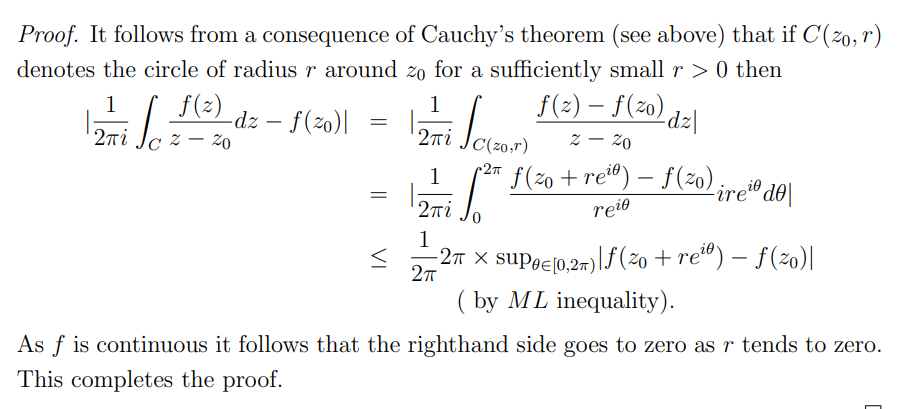

**(Click to expand proof)**

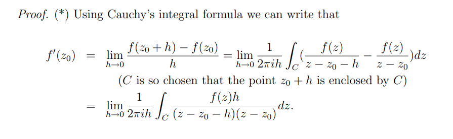

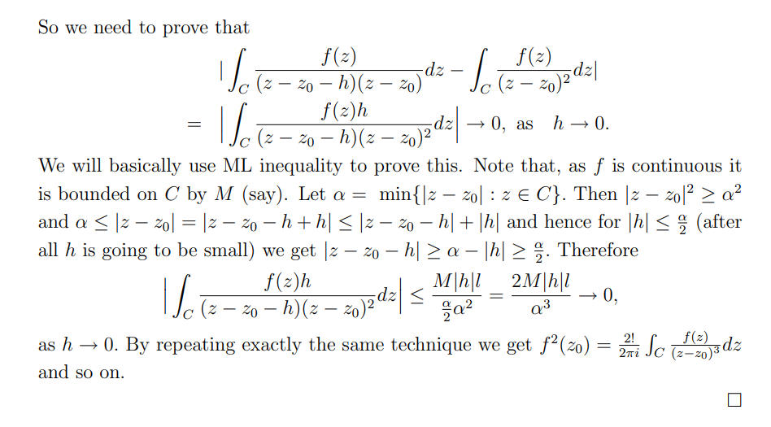

For $z_0 \in D_R(z_0) \subset \Omega$, setting $M \mathrel{\vcenter{:}}=\sup_{z\in \gamma}{\left\lvert {f(z)} \right\rvert}$ so ${\left\lvert {f(z)} \right\rvert}\leq M$ on $\gamma$
$$\begin{align*}
{\left\lvert { f^{(n)} (z_0) } \right\rvert}
\leq \frac{n !}{2 \pi} \int_{0}^{2 \pi} \frac{ M } {R^{n+1}} R \,d\theta
= \frac{M n ! }{R^n}
.\end{align*}$$

**(Click to expand proof)**

- Given $z_0\in \Omega$, pick the largest disc $D_R(z_0) \subset \Omega$ and let $C = {{\partial}}D_R$.
- Then apply the integral formula.

$$\begin{align*}
\left|f^{(n)}(z_0)\right|
&= {\left\lvert { \frac{n !}{2 \pi i} \int_{C} \frac{f(\zeta) }{(\zeta-z_0)^{n+1}} \,d\zeta} \right\rvert} \\
&=\left|\frac{n !}{2 \pi i} \int_{0}^{2 \pi} \frac{f\left(z_0 + r e^{i \theta}\right) r i e^{i \theta} }{\left(r e^{i \theta}\right)^{n+1}} \,d\theta\right| \\
&\leq \frac{n !}{2 \pi} \int_{0}^{2 \pi}\left|\frac{f\left( z_0 +r e^{i \theta}\right) r i e^{i \theta}}{\left(r e^{i \theta}\right)^{n+1}}\right| \,d\theta\\
&=\frac{n !}{2 \pi} \int_{0}^{2 \pi} \frac{\left|f\left(z_0 +r e^{i \theta}\right)\right|}{r^{n}} \,d\theta\\
&\leq \frac{n !}{2 \pi} \int_{0}^{2 \pi} \frac{M}{r^{n}} \,d\theta\\
&=\frac{M n !}{r^{n}}
.\end{align*}$$

The $n$th Taylor coefficient of an analytic function is at most $\sup_{{\left\lvert {z} \right\rvert} = R} {\left\lvert {f} \right\rvert}/R^n$.

If $f$ is holomorphic on $D_r(z_0)$
$$\begin{align*}
f(z_0)
= {1\over 2\pi} \int_0^{2\pi} f(z_0 + re^{i\theta}) \,d\theta
= {1\over \pi r^2} \iint_{D_r(z_0)} f(z)\, dA
.\end{align*}
Taking the real part of both sides, one can replace \(f=u+iv\) with \(u\).$$

### 4.2.2 Liouville

If $f$ is entire and bounded, $f$ is constant.

**(Click to expand proof)**

- Since $f$ is bounded, $f(z) \leq M$ uniformly on ${\mathbb{C}}$.
- Apply Cauchy’s estimate for the 1st derivative:
  $$\begin{align*}
  {\left\lvert {f'(z)} \right\rvert} \leq { 1! {\left\lVert {f} \right\rVert}_{C_R} \over R } \leq {M \over R}\overset{R\to\infty}\longrightarrow 0
  ,\end{align*}
  so \(f'(z) = 0\) for all \(z\).$$

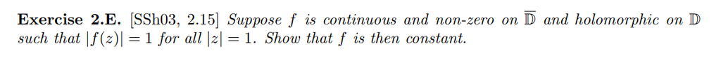

### 4.2.3 Continuation Principle

If $f$ is holomorphic on a bounded connected domain $\Omega$ and there exists a sequence $\left\{{z_i}\right\}$ with a limit point in $\Omega$ such that $f(z_i) = 0$, then $f\equiv 0$ on $\Omega$.

Two functions agreeing on a set with a limit point are equal on a domain.

**(Click to expand proof)**

Apply Improved Taylor Theorem?

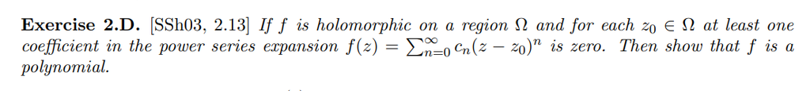

## 4.3 Exercises

Show that if $f$ has a primitive $F$ on $\Omega$ then $\int_\gamma f = 0$ for every closed curve $\gamma \subseteq \Omega$.

Prove the uniform limit theorem for holomorphic functions: if $f_n\to f$ locally uniformly and each $f_n$ is holomorphic then $f$ is holomorphic.

**(Click to expand solution)**

This is S&S Theorem 5.2. Statement: if $f_n\to f$ uniformly locally uniformly on $\Omega$ then $f$ is holomorphic on $\Omega$.

- Let $D \subset \Omega$ with $\mkern 1.5mu\overline{\mkern-1.5mu{\mathbb{D}}\mkern-1.5mu}\mkern 1.5mu\subset \Omega$ and $\Delta \subset D$ be a triangle.
- Apply Goursat: $\int_\Delta f_n = 0$.
- $f_n\to f$ uniformly on $\Delta$ since it is closed and bounded and thus compact by Heine-Borel, so $f$ is continuous and
  $$\begin{align*}
  \lim_n \int_\Delta f_n = \int_\Delta \lim_n f_n \mathrel{\vcenter{:}}=\int_\Delta f
  .\end{align*}$$
- Apply Morera’s theorem: $\int_\Delta f$ vanishes on every triangle in $\Omega$, so $f$ is holomorphic on $\Omega$.

Prove that if $f_n\to f$ locally uniformly with $f_n$ holomorphic, then $f_n'\to f'$ locally uniformly and $f'$ is holomorphic.

**(Click to expand solution)**

- Simplifying step: for some reason, it suffices to assume $f_n\to f$ uniformly on all of $\Omega$?
- Take $\Omega_R$ to be $\Omega$ with a buffer of $R$, so $d(z, {{\partial}}\Omega) > R$ for every $z \in \mkern 1.5mu\overline{\mkern-1.5mu\Omega_R\mkern-1.5mu}\mkern 1.5mu$.
- It suffices to show the following bound for $F$ any holomorphic function on $\Omega$:
  $$\begin{align*}
  \sup_{z\in \Omega_R} {\left\lvert {F'(z)} \right\rvert} \leq {1\over R} \sup_{\zeta \in \Omega} {\left\lvert {F(\zeta)} \right\rvert} && \forall R
  ,\end{align*}
  where on the right we take the sup over all \(\Omega\).$$
  - Then take $F \mathrel{\vcenter{:}}= f_n-f$ and $R\to 0$ to conclude, since the right-hand side is a constant not depending on $\Omega_R$.
- For any $z\in \Omega_R$, we have $\mkern 1.5mu\overline{\mkern-1.5muD_R(z)\mkern-1.5mu}\mkern 1.5mu \subseteq \Omega_R$, so Cauchy’s integral formula can be applied:
- $$\begin{align*}
  {\left\lvert {F'(z)} \right\rvert}
  &= {\left\lvert { {1\over 2\pi i} \int_{{{\partial}}D_R(z)} {F(\xi) \over (\xi-z)^2 } \,d\xi} \right\rvert} \\
  &\leq {1\over 2\pi} \int_{{{\partial}}D_R(z)} { { {\left\lvert {F(\xi)} \right\rvert} \over {\left\lvert {\xi-z} \right\rvert}^2 }} \,d\xi\\
  &\leq {1\over 2\pi} \int_{{{\partial}}D_R(z)} { { \sup_{\zeta\in \Omega} {\left\lvert {F(\zeta)} \right\rvert} \over {\left\lvert {\xi-z} \right\rvert}^2 }} \,d\xi\\
  &= {1\over 2\pi} \sup_{\zeta\in \Omega} {\left\lvert {F(\zeta)} \right\rvert} \int_{{{\partial}}D_R(z)} { { 1 \over R^2 }} \,d\xi\\
  &= {1\over 2\pi} \sup_{\zeta\in \Omega} {\left\lvert {F(\zeta)} \right\rvert} {1\over R^2} \int_{{{\partial}}D_R(z)} \,d\xi\\
  &= {1\over 2\pi} \sup_{\zeta\in \Omega} {\left\lvert {F(\zeta)} \right\rvert} {1\over R^2} 2\pi R \\
  &\leq {1\over 2\pi} \sup_{\zeta\in \Omega} {\left\lvert {F(\zeta)} \right\rvert} {1\over R^2}\qty{ 2\pi R} \\
  &= {1\over R} \sup_{\zeta \in \Omega}{\left\lvert {F(\zeta)} \right\rvert}
  .\end{align*}$$
- Now
  $$\begin{align*}
  {\left\lVert {f_n' - f'} \right\rVert}_{\infty, \Omega_R} \leq {1\over R} {\left\lVert {f_n - f} \right\rVert}_{\infty, \Omega}
  ,\end{align*}
  where if \(R\) is fixed then by uniform convergence of \(f_n\to f\), for \(n\) large enough \({\left\lVert {f_n - f} \right\rVert} < {\varepsilon}/R\).$$

## 4.4 Morera’s Theorem

If $f$ is continuous on a domain $\Omega$ and $\int_T f = 0$ for every triangle $T\subset \Omega$, then $f$ is holomorphic.

If every integral along a triangle vanishes, implies holomorphic.

If $\left\{{ f_n }\right\}_{n\in {\mathbb{N}}}$ is a holomorphic sequence on a region $\Omega$ which uniformly converges to $f$ on every compact subset $K \subseteq \Omega$, then $f$ is holomorphic, and $f_n' \to f'$ uniformly on every such compact subset $K$.

**(Click to expand proof)**

Commute limit with integral and apply Morera’s theorem.

This can be applied to series of the form $\sum_k f_k(z)$.

### 4.4.1 Symmetric Regions

In this section, take $\Omega$ to be a region symmetric about the real axis, so $z\in \Omega \iff \mkern 1.5mu\overline{\mkern-1.5muz\mkern-1.5mu}\mkern 1.5mu \in \Omega$. Partition this set as $\Omega^+ \subseteq {\mathbb{H}}, I \subseteq {\mathbb{R}}, \Omega^- \subseteq \mkern 1.5mu\overline{\mkern-1.5mu{\mathbb{H}}\mkern-1.5mu}\mkern 1.5mu$.

Suppose that $f^+$ is holomorphic on $\Omega^+$ and $f^-$ is holomorphic on $\Omega^-$, and $f$ extends continuously to $I$ with $f^+(x) = f^-(x)$ for $x\in I$. Then the following piecewise-defined function is holomorphic on $\Omega$:
$$\begin{align*}
f(z)
\mathrel{\vcenter{:}}=
\begin{cases}
f^+(z) & z\in \Omega^+
\\
f^-(z) & z\in \Omega^-
\\
f^+(z) = f^-(z) & z\in I.
\end{cases}
\end{align*}$$

**(Click to expand proof)**

Apply Morera?

If $f$ is continuous and holomorphic on ${\mathbb{H}}^+$ and real-valued on ${\mathbb{R}}$, then the extension defined by $F^-(z) = \mkern 1.5mu\overline{\mkern-1.5muf(\mkern 1.5mu\overline{\mkern-1.5muz\mkern-1.5mu}\mkern 1.5mu)\mkern-1.5mu}\mkern 1.5mu$ for $z\in {\mathbb{H}}^-$ is a well-defined holomorphic function on ${\mathbb{C}}$.

**(Click to expand proof)**

Apply the symmetry principle.

${\mathbb{H}}^+, {\mathbb{H}}^-$ can be replaced with any region symmetric about a line segment $L\subseteq {\mathbb{R}}$.

# 5 Zeros and Singularities

A point $z_0$ is an **isolated singularity** if $f(z_0)$ is undefined but $f(z)$ is defined in a punctured neighborhood $D(z_0)\setminus\left\{{z_0}\right\}$ of $z_0$.

There are three types of isolated singularities:

- Removable singularities
- Poles
- Essential singularities

If $z_0$ is a singularity of $f$. then $z_0$ is a **removable singularity** iff there exists a holomorphic function $g$ such that $f(z) = g(z)$ in a punctured neighborhood of $z_0$. Equivalently,
$$\begin{align*}
\lim_{z\to z_0}(z-z_0) f(z) = 0
.\end{align*}
Equivalently, \(f\) is bounded on a neighborhood of \(z_0\).$$

Singularities can be classified by Laurent expansions $f(z) = \sum_{k\in {\mathbb{Z}}} c_k z^k$:

- Essential singularity: infinitely many negative terms.
- Pole of order $N$: truncated at $k = -N$, so $c_{N-\ell} = 0$ for all $\ell$.
- Removable singularity: truncated at $k=0$, so $c_{\leq -1} = 0$.
- $f(z) \mathrel{\vcenter{:}}=\sin(z)/z$ has a removable singularity at $z=0$, and one can redefine $f(0) \mathrel{\vcenter{:}}= 1$.
- If $f(z) = p(z)/q(z)$ with $q(z_0)=0$ and $p(z_0)=0$, then $z_0$ is removable with $f(z_0)\mathrel{\vcenter{:}}= p'(z_0)/q'(z_0)$.

$f(z) \mathrel{\vcenter{:}}= e^{1/z}$ has an essential singularity at $z=0$, since we can expand and pick up infinitely many negative terms:
$$\begin{align*}
e^{1/z} = 1 + {1\over z} + {1\over 2! z^2} + \cdots
.\end{align*}
In fact there exists a neighborhood of zero such that \(f(U) = {\mathbb{C}}\setminus\left\{{0}\right\}\). Similarly \(g(z) \mathrel{\vcenter{:}}=\sin\qty{1\over z}\) has an essential singularity at \(z=0\), and there is a neighborhood \(V\) of zero such that \(g(V) = {\mathbb{C}}\).$$

The singularities of a rational function are always isolated, since there are finitely many zeros of any polynomial. The function $F(z) \mathrel{\vcenter{:}}=\operatorname{Log}(z)$ has a singularity at $z=0$ that is **not** isolated, since every neighborhood intersects the branch cut $(-\infty, 0) \times\left\{{ 0 }\right\}$, where $F$ is not even defined. The function $G(z) \mathrel{\vcenter{:}}= 1/\sin(\pi/z)$ has a non-isolated singularity at 0 and isolated singularities at $1/n$ for all $n$.

$f(z) \mathrel{\vcenter{:}}= z^{1\over 2}$ has a singularity at zero that does not fall under this classification – $z=0$ is a **branch singularity** and admits no Laurent expansion around $z=0$.

A similar example: $\qty{z(z-1)}^{1\over 2}$ has two branch singularities at $z=0, 1$.

If $f$ is holomorphic on $\Omega\setminus\left\{{z_0}\right\}$ where $z_0$ is a removable singularity, then there is a unique holomorphic extension of $f$ to all of $\Omega$.

**(Click to expand proof)**

Take $\gamma$ to be a circle centered at $z_0$ and use
$$\begin{align*}
f(z) \mathrel{\vcenter{:}}=\int_\gamma { f(\xi) \over \xi - z} \,dx
.\end{align*}
This is valid for \(z\neq z_0\), but the right-hand side is analytic. (?)$$

If $f$ is analytic on a region $\Omega$ containing $z_0$, then $f$ can be written as
$$\begin{align*}
f(z)
=\left(\sum_{k=0}^{n-1} \frac{f^{(k)}\left(z_{0}\right)}{k !}\left(z-z_{0}\right)^{k}\right)+
R_{n}(z)\left(z-z_{0}\right)^{n}
,\end{align*}
where \(R_n\) is analytic.$$

If $f$ is analytic and not identically zero on $\Omega$ with $f(z_0) = 0$, then there exists a nonvanishing holomorphic function $g$ such that
$$\begin{align*}
f(z) = (z-z_0)^n g(z)
.\end{align*}
We refer to \(z_0\) as a zero of order \(n\).$$

A *pole* $z_0$ of a function $f(z)$ is a zero of $g(z) \mathrel{\vcenter{:}}={1\over f(z)}$. Equivalently, $\lim_{z\to z_0} f(z) = \infty$. In this case there exists a minimal $n$ and a holomorphic $h$ such that \begin{align*} f(z) = \qty{z-z_0}^{-n} h(z) .\end{align*} Such an $n$ is the *order* of the pole. A pole of order 1 is said to be a *simple pole*.

If $f$ has a pole of order $n$ at $z_0$, then there exist a holomorphic $G$ in a neighborhood of $z_0$ such that
$$\begin{align*}
f(z) = {a_{-n} \over (z-z_0)^n } + \cdots + {a_{-1} \over z-z_0} + G(z) \mathrel{\vcenter{:}}= P(z) + G(z)
.\end{align*}$$

The term $P(z)$ is referred to as the *principal part of $f$ at $z_0$* consists of terms with negative degree, and the *residue* of $f$ at $z_0$ is the coefficient $a_{-1}$.

A singularity $z_0$ is *essential* iff it is neither removable nor a pole. Equivalently, a Laurent series expansion about $z_0$ has a principal part with infinitely many terms.

If $f$ is holomorphic on $\Omega\setminus\left\{{z_0}\right\}$ where $z_0$ is an essential singularity, then for every $V\subset \Omega\setminus\left\{{z_0}\right\}$, $f(V)$ is dense in ${\mathbb{C}}$.

The image of a punctured disc at an essential singularity is dense in ${\mathbb{C}}$.

**(Click to expand proof)**

Pick $w\in {\mathbb{C}}$ and suppose toward a contradiction that $D_R(w) \cap f(V)$ is empty. Consider
$$\begin{align*}
g(z) \mathrel{\vcenter{:}}={1\over f(z) - w}
,\end{align*}
and use that it’s bounded to conclude that \(z_0\) is either removable or a pole for \(f\).$$

For any $f$ holomorphic on an unbounded region, we say $z=\infty$ is a singularity (of any of the above types) of $f$ if $g(z) \mathrel{\vcenter{:}}= f(1/z)$ has a corresponding singularity at $z=0$.

A function $f:\Omega\to{\mathbb{C}}$ is *meromorphic* iff there exists a sequence $\left\{{z_n}\right\}$ such that

- $\left\{{z_n}\right\}$ has no limit points in $\Omega$.
- $f$ is holomorphic in $\Omega\setminus\left\{{z_n}\right\}$.
- $f$ has poles at the points $\left\{{z_n}\right\}$.

Equivalently, $f$ is holomorphic on $\Omega$ with a discrete set of points delete which are all poles of $f$.

Meromorphic functions on ${\mathbb{C}}$ are rational functions.

**(Click to expand proof)**

Consider $f(z) - P(z)$, subtracting off the principal part at each pole $z_0$, to get a bounded entire function and apply Liouville.

A singularity of a holomorphic function is removable if and only if the function is bounded in some punctured neighborhood of the singular point.

# 6 Counting Zeros and Poles

## 6.1 Argument Principle

The **logarithmic derivative** is defined as
$$\begin{align*}
{\partial}_{\log} f \mathrel{\vcenter{:}}={f' \over f}
.\end{align*}
It converts all poles and zeros of \(f\) into simple poles of \({\partial}_{\log f}\).$$

Show that ${\partial}_{\log}(fg) = {\partial}_{\log} f + {\partial}_{\log} g$, i.e.
$$\begin{align*}
{ (fg)' \over fg} = {f'\over f} + {g' \over g}
.\end{align*}$$

For $\gamma \subseteq \Omega$ a closed curve not passing through a point $z_0$, the **winding number of $\gamma$ about $z_0$** (or the **index**) is defined as
$$\begin{align*}
\mathop{\mathrm{Ind}}_{z=z_0}(\gamma) \mathrel{\vcenter{:}}={1\over 2\pi i} \int_\gamma {1\over \xi -z_0}\,d\xi
.\end{align*}$$

For $f$ meromorphic in $\Omega$ with multisets of zeros $Z_f \mathrel{\vcenter{:}}=\left\{{ z_j }\right\}$ and poles $P_f\mathrel{\vcenter{:}}=\left\{{ p_k }\right\}$ (so repeated with multiplicity) for $\gamma \mathrel{\vcenter{:}}={{\partial}}\Omega$ not intersect
$$\begin{align*}
{1\over 2\pi i} \int_\gamma {\partial}_{\log} f(z) \,dz
&= \# Z_f - \# P_f
,\end{align*}
where \(\# Z_f\) and \(\# P_f\) are the number of zeros and poles respectively, counted with multiplicity.$$

**(Click to expand proof)**

- If $z_0$ is a zero of $f$ of order $m$, write $f(z) = (z-z_0)^m g(z)$ with $g(z)$ holomorphic and nonzero on some neighborhood of $z_0$.
- Compute
  $$\begin{align*}
  {\partial}_{\log} f(z)
  &=
  \frac{m\left(z-z_{0}\right)^{m-1} g(z)+\left(z-z_{0}\right)^{m} g^{\prime}(z)}{\left(z-z_{0}\right)^{m} g(z)} \\
  &= {m \over z-z_0} + {\partial}_{\log} g(z)
  ,\end{align*}
  so \(z_0\) is a simple pole of \({\partial}_{\log} f\) and \(\mathop{\mathrm{res}}_{z=z_0} {\partial}_{\log} f = m\).$$
- If $z_0$ is a pole of $f$ of order $m$, write $f(z) = (z-z_0)^{-m} g(z)$, then
  $$\begin{align*}
  {\partial}_{\log} f = {-m \over z-z_0} + {\partial}_{\log} g
  ,\end{align*}
  so \(z_0\) is a simple pole and \(\mathop{\mathrm{Res}}_{z=z_0} {\partial}_{\log f} = -m\).$$
- Now apply the residue theorem, and group residues according to sign:
  $$\begin{align*}
  {1\over 2\pi i } \int_{\gamma} {\partial}_{\log }f(z) \,dz
  &= \sum_{z_i \in P_{{\partial}_{\log} f}} \mathop{\mathrm{Res}}_{z=z_i} {\partial}_{\log} f(z)\\
  &= \sum_{z_k \in Z_f} \mathop{\mathrm{Res}}_{z=z_k} f(z) - \sum_{z_j \in P_f} \mathop{\mathrm{Res}}_{z=z_j} f(z)
  .\end{align*}$$

With the same setup as above,
$$\begin{align*}
{1\over 2\pi i} \int_\gamma {\partial}_{\log} f(z) \,dz
&= \mathop{\mathrm{Ind}}_{w=0}(f\circ \gamma)(w)
.\end{align*}$$

**(Click to expand proof)**

Make the change of variables $w = f(z)$, then $z=\gamma(t) \mapsto w = (f\circ \gamma)(t)$ and $\,dw= f'(z) \,dz$, so
$$\begin{align*}
{1\over 2\pi i }\int_{\gamma} {\partial}_{\log} f(z) \,dz
= {1\over 2\pi i} \int_{f\circ \gamma} {1\over w} \,dw\mathrel{\vcenter{:}}=\mathop{\mathrm{Ind}}_{w=0} (f\circ \gamma)(w)
.\end{align*}$$

Let $f(z) = z^2 + z = z(z+1)$.

- $\gamma_1 \mathrel{\vcenter{:}}=\left\{{{\left\lvert {z} \right\rvert} = 2}\right\}$ contains 2 zeros and 0 poles, so $f\circ \gamma$ winds twice around zero counterclockwise.
- $\gamma_2 \mathrel{\vcenter{:}}=\left\{{{\left\lvert {z} \right\rvert} = {1\over 2}}\right\}$ contains 1 zero and 0 poles, so $f\circ \gamma$ winds once.

## 6.2 Rouché

If

- $f, g$ are meromorphic on $\Omega$
- $\gamma \subset \Omega$ is a toy contour winding about each zero/pole of $f, g$ exactly once,
- ${\left\lvert {g} \right\rvert} < {\left\lvert {f} \right\rvert}$ on $\gamma$

then
$$\begin{align*}
\mathop{\mathrm{Ind}}_{z=0}(f\circ \gamma)(z) = \mathop{\mathrm{Ind}}_{z=0}((f+g)\circ \gamma)(z) \implies Z_f - P_f = Z_{f+g} - P_{f+g}
.\end{align*}
In particular, if \(f, g\) are holomorphic, they have the same number of zeros in \(\Omega\).$$

The number of zeros/poles are determined by a dominating function.

Show that $h(z) =z^5 + 3z + 1$ has 5 zeros in ${\left\lvert {z} \right\rvert} \leq 2$.

Show that $h(z) = z + 3 + 2e^z$ has one root in $\left\{{ \Re(z) \leq 0}\right\}$.

**(Click to expand solution)**

Use the following contour:

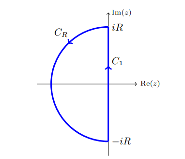

Take $g(z) \mathrel{\vcenter{:}}= 2e^z < f(z) \mathrel{\vcenter{:}}= f(z) \mathrel{\vcenter{:}}= z+3$.

Any holomorphic non-constant map is an open map.

If $f$ is holomorphic and nonconstant on an open connected region $\Omega$, then ${\left\lvert {f} \right\rvert}$ can not attain a maximum on $\Omega$. If $\Omega$ is bounded and $f$ is continuous on $\mkern 1.5mu\overline{\mkern-1.5mu\Omega\mkern-1.5mu}\mkern 1.5mu$, then $\max_{\mkern 1.5mu\overline{\mkern-1.5mu\Omega\mkern-1.5mu}\mkern 1.5mu} {\left\lvert {f} \right\rvert}$ occurs on ${{\partial}}\Omega$. Conversely, if $f$ attains a local supremum at $z_0 \in \Omega$, then $f$ is constant on $\Omega$.

If $f$ is nonzero on $\Omega$, then $f$ attains a minimum on ${{\partial}}\Omega$. This follows from applying the MMP to $1/f$.

## 6.3 Counting Zeros

- Take $P(z) = z^4 + 6z + 3$.
- On ${\left\lvert {z} \right\rvert} < 2$:
  - Set $f(z) = z^4$ and $g(z) = 6z + 3$, then ${\left\lvert {g(z)} \right\rvert} \leq 6{\left\lvert {z} \right\rvert} + 3 = 15 < 16= {\left\lvert {f(z)} \right\rvert}$.
  - So $P$ has 4 zeros here.
- On ${\left\lvert {z} \right\rvert} < 1$:
  - Set $f(z) = 6z$ and $g(z) = z^4 + 3$.
  - Check ${\left\lvert {g(z)} \right\rvert} \leq {\left\lvert {z} \right\rvert}^4 + 3 = 4 < 6 = {\left\lvert {f(z)} \right\rvert}$.
  - So $P$ has 1 zero here.
- Claim: the equation $\alpha z e^z = 1$ where ${\left\lvert {\alpha} \right\rvert} > e$ has exactly one solution in ${\mathbb{D}}$.
- Set $f(z) = \alpha z$ and $g(z) = e^{-z}$.
- Estimate at ${\left\lvert {z} \right\rvert} =1$ we have ${\left\lvert {g} \right\rvert} ={\left\lvert {e^{-z}} \right\rvert} = e^{-\Re(z)} \leq e^1 < {\left\lvert {\alpha} \right\rvert} = {\left\lvert {f(z)} \right\rvert}$
- $f$ has one zero at $z_0 = 0$, thus so does $f+g$.

# 7 Residues

## 7.1 Basics

Check: do you need residues at all?? You may be able to just compute an integral!

- Directly by parameterization:
  $$\begin{align*}
  \int_\gamma f \,dz= \int_a^b f(z(t))\, z'(t) \,dt&& \text{for } z(t) \text{ a parameterization of } \gamma
  ,\end{align*}$$
- Finding a primitive $F$, then
  $$\begin{align*}
  \int_\gamma f = F(b) - F(a)
  .\end{align*}$$
  - Note: you can parameterize a circle around $z_0$ using
    $$\begin{align*}
    z= z_0 + re^{i \theta }
    .\end{align*}$$

The major fact that reduces integrals to residues:
$$\begin{align*}
\int_\gamma z^k \,dz= \int_0^{2\pi} e^{ik\theta} ie^{i\theta } \,d\theta= i\int_0^{2\pi} e^{i(k+1)\theta \,d\theta}
=
\begin{cases}
2\pi i & k=-1
\\
0 & \text{else}.
\end{cases}
\end{align*}
Thus
\begin{align*}
\int \sum_{k\geq -M} c_k z^k = \sum_{k\geq -M} \int c_k z^k = 2\pi i c_{-1}
,\end{align*}
i.e. the integral picks out the \(c_{-1}\) coefficient in a Laurent series expansion.$$

Consider
$$\begin{align*}
f(z) \mathrel{\vcenter{:}}={e^{iz} \over 1 + z^2}
\end{align*}
where \(z\neq \pm i\), and attempt to integrate
\begin{align*}
\int_{\mathbb{R}}f(z) \,dz
.\end{align*}
Use a semicircular contour \(\gamma_R\) where \(z = Re^{it}\) and check
\begin{align*}
\sup_{z\in \gamma_R} {\left\lvert {f(z)} \right\rvert}
&= \max_{t\in [0, \pi} {1 \over 1 + (Re^{it})^2 } \\
&= \max_{t\in [0, \pi} {1 \over 1 + R^2e^{2it} } \\
&= {1\over R^2 - 1}
.\end{align*}$$

## 7.2 Estimates

$$\begin{align*}
{\left\lvert { \int_\gamma f} \right\rvert} \leq ML \mathrel{\vcenter{:}}=\sup_{z\in \gamma} {\left\lvert {f} \right\rvert} \cdot \mathrm{length}(\gamma)
.\end{align*}$$

**(Click to expand proof)**

$$\begin{align*}
\left|\int_{\gamma} f(z) d z\right| \leq \sup _{t \in[a, b]}|f(z(t))| \int_{a}^{b}\left|z^{\prime}(t)\right| d t \leq \sup _{z \in \gamma}|f(z)| \cdot \operatorname{length}(\gamma)
.\end{align*}$$

Suppose that $f(z) = e^{iaz}g(z)$ for some $g$, and let $C_R \mathrel{\vcenter{:}}=\left\{{ z=Re^{it} {~\mathrel{\Big|}~}t\in [0, \pi] }\right\}$. Then
$$\begin{align*}
{\left\lvert {\int_{C_R} f(z) \,dz} \right\rvert} \leq {\pi M_R \over a}
\end{align*}
where \(M_R \mathrel{\vcenter{:}}=\sup_{t\in [0, \pi]} {\left\lvert {g(Re^{it})} \right\rvert}\).$$

**(Click to expand proof)**

$$\begin{align*}
{\left\lvert { \int_{C_R} f(z)\,dz} \right\rvert}
&= {\left\lvert { \int_{C_R} e^{iaz}g(z) \,dz} \right\rvert} \\
&= {\left\lvert { \int_{[0, \pi]} e^{ia\qty{Re^{it}}}g(Re^{it}) iRe^{it} \,dt} \right\rvert} \\
&\leq \int_{[0, \pi]} {\left\lvert { e^{ia\qty{Re^{it}}}g(Re^{it}) iRe^{it}} \right\rvert} \,dt\\
&=R \int_{[0, \pi]} {\left\lvert { e^{ia\qty{Re^{it}}}g(Re^{it})} \right\rvert} \,dt\\
&\leq R M_R \int_{[0, \pi]} {\left\lvert { e^{ia\qty{Re^{it}}}} \right\rvert} \,dt\\
&= R M_R \int_{[0, \pi]} e^{\Re\qty{iaRe^{it}}} \,dt\\
&= R M_R \int_{[0, \pi]} e^{\Re\qty{iaR\qty{\cos(t) + i\sin(t) } }} \,dt\\
&= R M_R \int_{[0, \pi]} e^{-aR\sin(t) } \,dt\\
&= 2 R M_R \int_{[0, \pi/2]} e^{-aR\sin(t) } \,dt\\
&\leq 2R M_R \int_{[0, \pi/2]} e^{-aR\qty{2t\over \pi} } \,dt\\
&= 2RM_R \qty{\pi \over 2aR}\qty{1-e^{-aR}} \\
&= {\pi M_R \over a}
.\end{align*}$$

where we’ve used that on $[0, \pi/2]$, there is an inequality $2t/\pi \leq \sin(t)$. This is obvious from a picture, since $\sin(t)$ is a height on $S^1$ and $2t/\pi$ is a height on a diagonal line:

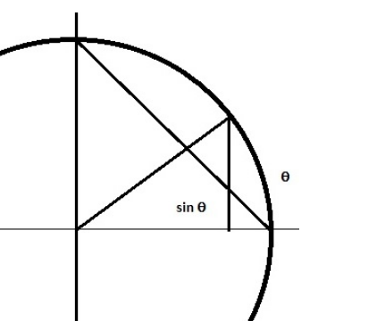

## 7.3 Residue Formulas

Let $f$ be meromorphic on a region $\Omega$ with poles $\left\{{ { {z}_1, {z}_2, \cdots, {z}_{N}} }\right\}$. Then for any $\gamma \in \Omega\setminus\left\{{ { {z}_1, {z}_2, \cdots, {z}_{N}} }\right\}$,
$$\begin{align*}
{1 \over 2\pi i } \int_\gamma f(z) \,dz= \sum_{j=1}^N n_\gamma(z_j) \mathop{\mathrm{Res}}_{z=z_j} f
.\end{align*}
If \(\gamma\) is a toy contour, then
\begin{align*}
{1\over 2\pi i}\int_\gamma f\,dz= \sum_{j=1}^N \mathop{\mathrm{Res}}_{z=z_j}f
.\end{align*}$$

If $f$ has a pole $z_0$ of order $n$, then
$$\begin{align*}
\mathop{\mathrm{Res}}_{z=z_0} f = \lim_{z\to z_0} {1 \over (n-1)!} \qty{{\frac{\partial }{\partial z}\,}}^{n-1} (z-z_0)^n f(z)
.\end{align*}$$

As a special case, if $z_0$ is a simple pole of $f$, then
$$\begin{align*}
\mathop{\mathrm{Res}}_{z=z_0}f = \lim_{z\to z_0} (z-z_0) f(z)
.\end{align*}$$

If additionally $f=g/h$ where $h(z_0) = 0$ and $h'(z_0)\neq 0$,
$$\begin{align*}
\mathop{\mathrm{Res}}_{z=z_0} {g(z) \over h(z)} = {g(z_0) \over h'(z_0)}
.\end{align*}$$

**(Click to expand proof)**

Apply L’Hopital:
$$\begin{align*}
(z-z_0) {g(z) \over h(z)} = {(z-z_0) g(z) \over h(z) } \overset{LH}{=}
{g(z) + (z-z_0) g'(z) \over h'(z)} \overset{z\to z_0}\longrightarrow{g(z_0) \over h'(z_0)}
.\end{align*}$$

Let $f(z) = \frac{1}{1+z^2}$, then $g(z) = 1, h(z) = 1+z^2$, and $h'(z) = 2z$ so that $h'(i) = 2i \neq 0$. Thus
$$\begin{align*}
\mathop{\mathrm{Res}}_{z=i}{1\over 1+z^2} = \frac{1}{2i}
.\end{align*}$$

$$\begin{align*}
\mathop{\mathrm{Res}}_{z=\infty}f(z) = \mathop{\mathrm{Res}}_{z=0} g(z) && g(z) \mathrel{\vcenter{:}}=-{1 \over z^2}f\qty{1\over z}
.\end{align*}$$

### 7.3.1 Exercises

> Some good computations [here](https://math.mit.edu/~jorloff/18.04/notes/topic9.pdf).

Show that the complex zeros of $f(z) \mathrel{\vcenter{:}}=\sin(\pi z)$ are exactly ${\mathbb{Z}}$, and each is order 1. Calculate the residue of $1/\sin(\pi x)$ at $z=n\in {\mathbb{Z}}$.

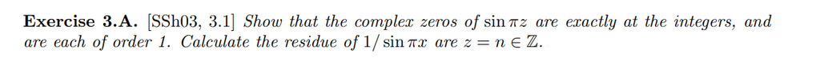

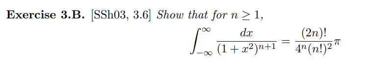

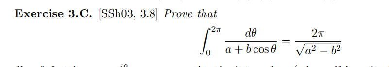

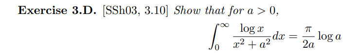

$$\begin{align*}
\int_{\mathbb{R}}{1 \over (1+x^2)^2} \,dx
.\end{align*}$$

**(Click to expand solution)**

- Factor $(1+z^2)^2 = ((z-i)(z+i))^2$, so $f$ has poles at $\pm i$ of order 2.
- Take a semicircular contour $\gamma \mathrel{\vcenter{:}}= I_R \cup D_R$, then $f(z) \approx 1/z^4 \to 0$ for large $R$ and $\int_{D_R} f \to 0$.
- Note $\int_{I_R} f \to \int_{\mathbb{R}}f$, so $\int_\gamma f \to \int_{\mathbb{R}}f$.
- $\int_\gamma f = 2\pi i \sum_{z_0} \mathop{\mathrm{Res}}_{z=z_0} f$, and $z_0 = i$ is the only pole in this region.
- Compute
  $$\begin{align*}
  \mathop{\mathrm{Res}}_{z=i} f
  &= \lim_{z\to i} {1\over (2-1)!} {\frac{\partial }{\partial z}\,} (z-i)^2 f(z) \\
  &= \lim_{z\to i} {\frac{\partial }{\partial z}\,} {1\over (z+i)^2 } \\
  &= \lim_{z\to i} {-2 \over (z+i)^3 } \\
  &= -{2 \over (2i)^3 } \\
  &= {1\over 4i} \\ \\
  \implies
  \int_\gamma f &= {2\pi i \over 4i} = \pi/2
  ,\end{align*}$$

Use a direct Laurent expansion to show
$$\begin{align*}
\mathop{\mathrm{Res}}_{z=0} {1\over z-\sin(z)} = {3! \over 5\cdot 4}
.\end{align*}$$

> Note the necessity: one doesn’t know the order of the pole at zero, so it’s unclear how many derivatives to take.

**(Click to expand solution)**

Expand:
$$\begin{align*}
{1\over z - \sin(z)}
&= z^{-1}\qty{1 - z^{-1}\sin(z) }^{-1}\\
&= z^{-1}\qty{1 - z^{-1}\qty{ z - {1\over 3!}z^3 + {1\over 5!} z^5 - \cdots}}^{-1}\\
&= z^{-1}\qty{1 - \qty{ 1 - {1\over 3!}z^2 + {1\over 5!} z^4 - \cdots}}^{-1}\\
&= z^{-1}\qty{{1\over 3!}z^2 - {1\over 5!}z^4 + \cdots}^{-1}\\
&= z^{-1}\cdot 3! z^{-2} \qty{1 - {1\over 5!/3!}z^2 + \cdots}^{-1}\\
&= {3!\over z^3} \qty{1 \over 1 - \qty{ {1\over 5\cdot 4}z^2 + \cdots}} \\
&= {3!\over z^3}\qty{1 + \qty{{1\over 5\cdot 4}z^2} + \qty{{1\over 5\cdot 4}z^2}^2 + \cdots} \\
&= 3! z^{-3} + {3!\over 5\cdot 4}z^{-1}+ O(z) \\
.\end{align*}$$

Compute
$$\begin{align*}
\mathop{\mathrm{Res}}_{z=0} {1\over z^2 \sin(z)}
.\end{align*}$$

**(Click to expand solution)**

First expand $(\sin(z))^{-1}$:
$$\begin{align*}
{1\over \sin(z)}
&= \qty{z - {1\over 3!}z^3 + {1\over 5!}z^5 -\cdots }^{-1}\\
&= z^{-1}\qty{1 - {1\over 3!}z^2 + {1\over 5!}z^4 - \cdots }^{-1}\\
&= z^{-1}\qty{1 +
\qty{{1\over 3!}z^2 - {1\over 5!} z^4 + \cdots}
+
\qty{{1\over 3!}z^2 - \cdots}^2 + \cdots
} \\
&= z^{-1}\qty{1 + {1\over 3!}z^2 \pm O(z^4) }
,\end{align*}
using that \((1-x)^{-1}= 1 + x + x^2 + \cdots\).$$

Thus
$$\begin{align*}
z^{-2}\qty{\sin(z)}^{-1}
&= z^{-2} \cdot
z^{-1}\qty{1 + {1\over 3!}z^2 \pm O(z^4) } \\
&= z^{-3} + {1\over 3!}z^{-1}+ O(z)
.\end{align*}$$

Compute
$$\begin{align*}
\int_{[0, \infty]} {\log(x) \over (1+x^2)^2}\,dx
.\end{align*}$$

**(Click to expand solution)**

Factor $(1+z^2)^2 = (z+i^2(z-i)^2$. Take a keyhole contour similar to the following:

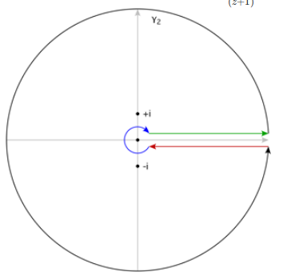

Show that outer radius $R$ and inner radius $\rho$ circles contribute zero in the limit by the ML estimate? Compute the residues by just applying the formula and manually computing derivatives:
$$\begin{align*}
\mathop{\mathrm{Res}}_{z= \pm i} f(z)
&= \lim_{z\to \pm i} {\frac{\partial }{\partial z}\,} {\log^2(z) \over (z\pm i)^2} \\
&= \lim_{z\to \pm i} {2\log(z) (z\pm i)^2 - 2(z\pm i)^2 \log^2(z) \over \qty{(z\pm i )^2}^2} \\
&= {
2\log(\pm i)(\pm 2i)^2 - 2(\pm 2i)^2 \log^2(\pm i)
\over {\qty{\pm 2i}}^4 } \\
&=_? {\pi \over 4}\pm {i\pi^2 \over 16}
.\end{align*}$$

> See p.4: http://www.math.toronto.edu/mnica/complex1.pdf

Show
$$\begin{align*}
\int_{(0, \infty)} {\sin(x) \over x }\,dx= {\pi \over 2}
.\end{align*}$$

**(Click to expand solution)**

Take an indented semicircle. Let $I$ be the original integral, then
$$\begin{align*}
I = {1\over 2i} \int_{\mathbb{R}}{e^{iz} - 1 \over z } \,dz
.\end{align*}$$

[figure not shown]

# 8 Integrals

[See this very detailed note](https://math.mit.edu/~jorloff/18.04/notes/topic9.pdf).

- For integrals that decay faster than $1/z^\alpha, \alpha>1$: semicircular contours.

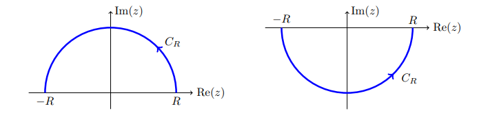

- For integrals that decay like $1/z$: rectangular contours.

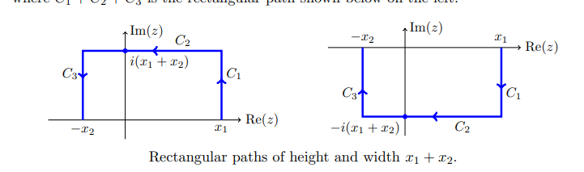

- If a trigonometric function is in the numerator, check if $I \approx \Re(\tilde I)$ where $\tilde I$ replaces cosines/sines with $e^{iz}$.
- For rational functions of $\cos, \sin$: set $2\cos(z) = z + z^{-1}, 2\sin(z) = z - z^{-1}, \,d\theta= {\,dz\over iz}$ to reduce to a residue count in ${\left\lvert {z} \right\rvert} \leq 1$.

$$\begin{align*}
\int_{\mathbb{R}}{1 \over (1+x)^2} = {\pi \over 2}
.\end{align*}$$

Use that $f(z) \sim 1/z^4$.

**(Click to expand solution)**

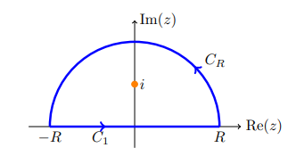

$$\begin{align*}
\int_{\mathbb{R}}{1 \over x^4 + 1} = {\pi \sqrt{2} \over 2}
.\end{align*}$$

**(Click to expand solution)**

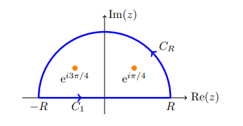

$$\begin{align*}
\int_{0}^{\infty} \frac{\cos (x)}{x^{2}+b^{2}} d x=\frac{\pi \mathrm{e}^{-b}}{2 b} .
.\end{align*}$$

**(Click to expand solution)**

Extend to $\int_{\mathbb{R}}$ using that $f$ is even.

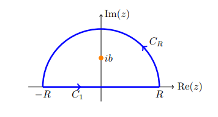

$$\begin{align*}
\int_{0}^{2 \pi} \frac{d \theta}{1+a^{2}-2 a \cos (\theta)}
= \begin{cases}\frac{2 \pi}{a^{2}-1} & \text { if }|a|>1 \\ \frac{2 \pi}{1-a^{2}} & \text { if }|a|<1\end{cases}
.\end{align*}$$

**(Click to expand solution)**

Write $2\cos(z) = z + z^{-1}$ on $S^1$ to get
$$\begin{align*}
=\int_{|z|=1} \frac{1}{i\left(\left(1+a^{2}\right) z-a\left(z^{2}+1\right)\right)} d z
.\end{align*}$$

## 8.1 Branch Cuts

$$\begin{align*}
\int_0^\infty {x^{1\over 3} \over 1 + x^2} \,dx= {\pi \over \sqrt 3}
.\end{align*}$$

**(Click to expand solution)**

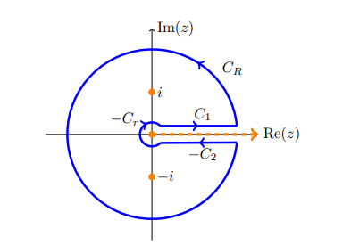

$$\begin{align*}
\int_{1}^{\infty} \frac{d x}{x \sqrt{x^{2}-1}} = {\pi \over 2}
.\end{align*}$$

**(Click to expand solution)**

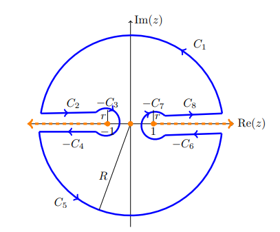

# 9 Conformal Maps / Linear Fractional Transformations

A map $f$ is **conformal** on $\Omega$ iff $f$ is complex-differentiable, $f'(z)\neq 0$ for $z\in \Omega$, and $f$ preserves signed angles (so $f$ is orientation-preserving). Conformal implies holomorphic, and a bijective conformal map has conformal inverse automatically.

A bijective conformal map $f:U\to V$ **biholomorphism**, and we say $U$ and $V$ are **biholomorphic**. Importantly, bijective holomorphic maps always have holomorphic inverses. Self-biholomorphisms of a domain $\Omega$ form a group $\mathop{\mathrm{Aut}}_{\mathbb{C}}(\Omega)$.

There is an oft-used weaker condition that $f'(z) \neq 0$ for any point. Note that that this condition alone doesn’t necessarily imply $f$ is holomorphic, since anti-holomorphic maps may have nonzero derivatives. For example, take $f(z) = \mkern 1.5mu\overline{\mkern-1.5muz\mkern-1.5mu}\mkern 1.5mu$, so $f(x+iy) = x-iy$ – this does not satisfy the Cauchy-Riemann equations.

A bijective holomorphic map automatically has a holomorphic inverse. This can be weakened: an injective holomorphic map satisfies $f'(z) \neq 0$ and $f ^{-1}$ is well-defined on its range and holomorphic.

A map of the following form is a *linear fractional transformation*:
$$\begin{align*}
T(z) = {az + b \over cz + d}
,\end{align*}
where the denominator is assumed to not be a multiple of the numerator. These have inverses given by
\begin{align*}
T^{-1}(w) = {dw-b \over -cw + a}
.\end{align*}$$

- $(z, i, 1, -1): {\mathbb{D}}\to {\mathbb{H}}$
- $(z, 0, -1, 1): {\mathbb{D}}\cap{\mathbb{H}}\to Q_1$.

The fractional linear transformation given by $F(z) = {i - z \over i + z}$ maps ${\mathbb{D}}\to {\mathbb{H}}$ with inverse $G(w) = i {1-w \over 1 + w}$.

Conformal maps ${\mathbb{D}}\to{\mathbb{D}}$ have the form
$$\begin{align*}
g(z) = \lambda {1-a \over 1 - \mkern 1.5mu\overline{\mkern-1.5mua\mkern-1.5mu}\mkern 1.5mu z}, \quad {\left\lvert {a} \right\rvert} < 1, \quad {\left\lvert {\lambda} \right\rvert} = 1
.\end{align*}$$

If $\Omega$ is simply connected, nonempty, and not ${\mathbb{C}}$, then for every $z_{0}\in \Omega$ there exists a unique conformal map $F:\Omega \to {\mathbb{D}}$ such that $F(z_{0}) = 0$ and $F'(z_{0}) > 0$.

Thus any two such sets $\Omega_{1}, \Omega_{2}$ are conformally equivalent.

## 9.1 By Type

| Notation | Definition |
| --- | --- |
| ${\mathbb{D}}\mathrel{\vcenter{:}}=\left\{{z {~\mathrel{\Big\|}~}{\left\lvert {z} \right\rvert} \leq 1}\right\}$ | The unit disc |
| ${\mathbb{H}}\mathrel{\vcenter{:}}=\left\{{x+iy {~\mathrel{\Big\|}~}y > 0}\right\}$ | The upper half-plane |
| $X_{1\over 2}$ | A “half version of $X$,” see examples |
| ${\mathbb{H}}_{1\over 2}$ | The first quadrant |
| ${\mathbb{D}}_{1\over 2}$ | The portion of the first quadrant inside the unit disc |
| $L \mathrel{\vcenter{:}}=\left\{{x + iy {~\mathrel{\Big\|}~}x\in {\mathbb{R}},\, 0<y<\pi}\right\}$ | The horizontal strip |

| Type/Domains | Formula |
| --- | --- |
| Translation | $z\mapsto z + h$ |
| Dilation | $z\mapsto cz$ |
| Rotation | $z\mapsto e^{i\theta}$ |
| Sectors to sectors | $z\mapsto z^n$ |
| ${\mathbb{D}}_{1\over 2} \to {\mathbb{H}}_{1\over 2}$, the first quadrant | $z\mapsto {1+z \over 1-z}$ |
| ${\mathbb{H}}\to S$ | $z\mapsto \log(z)$ |
| ${\mathbb{D}}_{1\over 2} \to L_{1\over 2}$ | $z\mapsto \log(z)$ |
| $S_{1\over 2} \to {\mathbb{D}}_{1\over 2}$ | $z\mapsto e^{iz}$ |
| ${\mathbb{D}}_{1\over 2} \to {\mathbb{H}}$ | $z\mapsto {1\over 2}\qty{z + {1\over z}}$ |
| $L_{1\over 2} \to {\mathbb{H}}$ | $z\mapsto \sin(z)$ |

$$\begin{align*}
F: {\mathbb{H}}^\circ &\rightleftharpoons{\mathbb{D}}^\circ \\
\left\{{z{~\mathrel{\Big|}~}\Im(z) > 0 }\right\} &\rightleftharpoons\left\{{w{~\mathrel{\Big|}~}{\left\lvert {w} \right\rvert} < 1 }\right\} \\
z &\mapsto {i-z \over i+z} \\
i \qty{1-w \over 1+w} &\mapsfrom w
.\end{align*}$$

**Boundary behavior:**

- This maps ${\mathbb{R}}\to {{\partial}}{\mathbb{D}}$, where $F(\infty) = -1$, and as $x\in {\mathbb{R}}$ ranges from $-\infty\to\infty$, $F(x)$ travels from $z=-1$ counter-clockwise through $S^1$ (starting at $z=-1$ and moving through the lower half first).

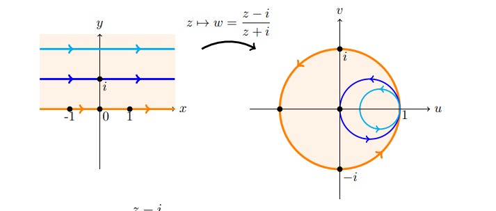

So this extends to a map ${\mathbb{H}}\to {\mathbb{D}}$.

> Mnemonic: every $z\in {\mathbb{H}}$ is closer to $i$ than $-i$.

Some write a similar map:
$$\begin{align*}
{\mathbb{H}}^\circ &\to {\mathbb{D}}^\circ \\
z &\mapsto {z-i \over z+i}
.\end{align*}
This is just a composition of the above map with the flip \(z\mapsto -z\):
\begin{align*}
- {i-z \over i + z} = {z-i \over i+z} = {z-i \over z+i}
.\end{align*}$$

$$\begin{align*}
{\mathbb{H}}_{R} &\rightleftharpoons{\mathbb{D}}\\
\left\{{ z {~\mathrel{\Big|}~}\Re(z) > 0 }\right\} &\rightleftharpoons\left\{{ w {~\mathrel{\Big|}~}{\left\lvert {w} \right\rvert} < 1 }\right\} \\
z &\mapsto {1-z \over 1+z} \\
{1-w\over 1+w} &\mapsfrom w
.\end{align*}$$

Just map the *right* half-plane ${\mathbb{H}}_R$ to the disc ${\mathbb{D}}$ by precomposing with a rotation $e^{i\pi/2} = i$:
$$\begin{align*}
{\mathbb{H}}_{R} \to {\mathbb{H}}&\to {\mathbb{D}}\\
z \mapsto iz &\mapsto {i- (iz) \over i + (iz)} = {i(1-z) \over i(1+z) } = {1-z \over 1+z}
.\end{align*}$$

This can easily be inverted:
$$\begin{align*}
&\quad w = {1+z \over 1+z} \\
&\implies -(1-w) + z(w+1) = 0 \\
&\implies z = {1-w \over 1+w}
.\end{align*}$$

**Boundary behavior**: Just a rotated version of ${\mathbb{H}}\to {\mathbb{D}}$!

> Mnemonic: every $z\in {\mathbb{H}}_R$ is closed to 1 than $-1$.

For $0 < \alpha < 2$:
$$\begin{align*}
F_\alpha: S_{\pi \over \alpha }^\circ &\rightleftharpoons S_{\pi}^\circ = {\mathbb{H}}^\circ \\
\left\{{z{~\mathrel{\Big|}~}0 < \operatorname{Arg}(z) < {\pi\over \alpha} }\right\} &\rightleftharpoons\left\{{w{~\mathrel{\Big|}~}0 < \operatorname{Arg}(w) < \pi }\right\} \\
z &\mapsto z^\alpha \\
w^{1\over \alpha} &\mapsfrom w
.\end{align*}
Note that if you look at the image of \({\mathbb{H}}\) under \(z\mapsto z^{\alpha}\), you get
\begin{align*}
\left\{{z {~\mathrel{\Big|}~}0 < \operatorname{Arg}(z) < \pi }\right\} &\rightleftharpoons\left\{{0 < \operatorname{Arg}(w) < \alpha \pi }\right\}
.\end{align*}
For the inverse, choose a branch cut of \(\log\) deleting the negative real axis, or more generally fix \(0 < \arg w < \alpha \pi\).$$

**Boundary behavior:**

- As $x$ travels from $-\infty\to 0$, $F_\alpha(x)$ travels *away* from infinity along the ray $\theta = \alpha \pi$, so $L = \left\{{ e^{t \alpha \pi } {~\mathrel{\Big|}~}t\in (0, \infty) }\right\}$, from $\infty\to 0$.
- As $x$ travels from $0\to \infty$, $F_\alpha(x)$ travels from $0\to \infty$ along ${\mathbb{R}}$.

The unmotivated formula first:
$$\begin{align*}
F: S_{\alpha} &\to {\mathbb{D}}\\ \\
\left\{{ z {~\mathrel{\Big|}~}0 < \operatorname{Arg}(z) < \alpha }\right\} &\rightleftharpoons\left\{{ w {~\mathrel{\Big|}~}{\left\lvert {w} \right\rvert} < 1 }\right\} \\
z &\rightleftharpoons{z^{\pi\over \alpha} - i \over z^{\pi\over\alpha} + i}
.\end{align*}$$

Idea: compose some known functions.

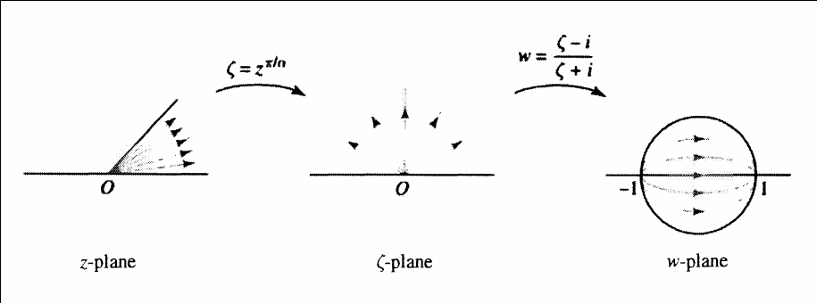

$$\begin{align*}
S_{\alpha} &\to S_{\pi} = {\mathbb{H}}\to {\mathbb{D}}\\
z &\mapsto z^{\pi \over \alpha} \mapsto {z-i\over z+i}\Big|_{z= z^{\pi\over \alpha}}
.\end{align*}$$

$$\begin{align*}
\left\{{ z {~\mathrel{\Big|}~}{\left\lvert {z} \right\rvert} < 1,\, \Im(z) > 0 }\right\} &\rightleftharpoons\left\{{ w {~\mathrel{\Big|}~}\Re(w)>0,\, \Im(w) > 0}\right\} \\
z &\mapsto {1+z \over 1-z} \\
{w-1\over w+1} &\mapsfrom w
.\end{align*}$$

- Why this lands in the first quadrant:
  - Use that squares are non-negative and $z=x+iy\in {\mathbb{D}}\implies x^2 + y^2 < 1$:
    $$\begin{align*}
    f(z)=\frac{1-\left(x^{2}+y^{2}\right)}{(1-x)^{2}+y^{2}}+i \frac{2 y}{(1-x)^{2}+y^{2}}
    .\end{align*}$$
- Why the inverse lands in the unit disc:
  - For $w$ in Q1, the distance from $w$ to 1 is smaller than from $w$ to $-1$.
  - Check that if $w=u+iv$ where $u, v>0$, the imaginary part of the image is positive:

$$\begin{align*}
{w-1 \over w+1}
&= { (w-1) \mkern 1.5mu\overline{\mkern-1.5mu(w+1)\mkern-1.5mu}\mkern 1.5mu \over {\left\lvert {w+1} \right\rvert}^2}\\
&={ \qty{u-1 + iv} \qty{u+1-iv} \over (u+1)^2 + v^2 } \\
&= {u^2 + v^2 + 1 \over (u+1)^2 + v^2}
+ i\qty{ 2v \over (u+1)^2 + v^2}
.\end{align*}$$

**Boundary behavior**:

- On the upper half circle $\left\{{ e^{it } {~\mathrel{\Big|}~}t\in (0, \pi) }\right\}$, write
  $$\begin{align*}
  f(z)=\frac{1+e^{i \theta}}{1-e^{i \theta}}=\frac{e^{-i \theta / 2}+e^{i \theta / 2}}{e^{-i \theta / 2}-e^{i \theta / 2}}=\frac{i}{\tan (\theta / 2)}
  ,\end{align*}
  so as \(t\) ranges \(0\to \pi\) we have \(f(z)\) ranging from \(0\to i\infty\) along the imaginary axis.$$
- As $x$ ranges from $-1\to 1$ in ${\mathbb{R}}$, $f(z)$ ranges from $0\to \infty$ with $f(0) = 1$.

$$\begin{align*}
{\mathbb{H}}&\rightleftharpoons{\mathbb{R}}\times(0, \pi) \\
\left\{{ z {~\mathrel{\Big|}~}\Im(z) > 0 }\right\} &\rightleftharpoons\left\{{ w {~\mathrel{\Big|}~}\Im(z) \in (0, \pi ) }\right\} \\
z &\mapsto \log(z) \\
e^w &\mapsfrom w
.\end{align*}$$

- Why this lands in a strip: use that $\arg(z) \in (0, \pi)$ and $\log(z) = {\left\lvert {z} \right\rvert} + i\arg(z)$.

**Boundary behavior**:

- As $x$ travels from $-\infty \to 0$, $F(x)$ travels horizontally from $\infty + i\pi$ to $-\infty + i\pi$.
- As $x$ travels from $o\to \infty$, $F(x)$ travels from $-\infty\to\infty$ in ${\mathbb{R}}$.

This extends to a function ${\mathbb{C}}\setminus{\mathbb{R}}^{\leq 0} \to {\mathbb{R}}\times(-\pi, \pi)$. Circles of radius $R$ are mapped to vertical line segments connecting $\ln(R) + i\pi$ to $\ln(R) - i\pi$, and rays are mapped to horizontal lines.

One can find other specific images of the logarithm:
$$\begin{align*}
\left\{{ z {~\mathrel{\Big|}~}{\left\lvert {z} \right\rvert} < 1,\, \Im(z) > 0 }\right\} &\rightleftharpoons{\mathbb{R}}^{<0} \times(0, \pi ) \\
\left\{{ z {~\mathrel{\Big|}~}{\left\lvert {z} \right\rvert} > 1,\, \Im(z) > 0 }\right\} &\rightleftharpoons{\mathbb{R}}^{>0} \times(0, \pi ) \\
.\end{align*}$$

For the upper half-disc to the negative horizontal half-strip: - As $x$ travels $0\to 1$ in ${\mathbb{R}}$, $\log(x)$ travels from $-\infty\to 0$. - As $x$ travels from $-1$ to $1$ along $S^1\cap{\mathbb{H}}$, $\log(x)$ travels from $0\to i\pi$ vertically. - As $x$ travels from $-1\to 0$, $\log(x)$ travels from $0+i\pi\to i-\infty+i\pi$ along the top of the strip.

$$\begin{align*}
F: (-{\pi\over 2}, {\pi \over 2}) \times{\mathbb{R}}^{>0} &\to {\mathbb{D}}\cap{\mathbb{H}}\\
z &\mapsto e^{iz} \\
{\log(w) \over i}? &\mapsfrom w
.\end{align*}$$

This uses that $e^{iz} = e^{-\Im(z)} e^{i \Re(z)}$.

**Boundary behavior**:

## 9.2 Exercises

Find a conformal map from the upper half-disc to the upper half-plane.

**(Click to expand solution)**

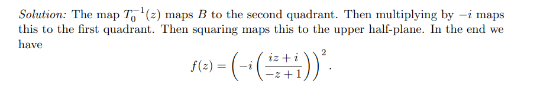

# 10 Schwarz Reflection

## 10.1 Schwarz

If $f: {\mathbb{D}}\to {\mathbb{D}}$ is holomorphic with $f(0) = 0$, then

1. ${\left\lvert {f(z)} \right\rvert} \leq {\left\lvert {z} \right\rvert}$ for all $z\in {\mathbb{D}}$
2. ${\left\lvert {f'(0)} \right\rvert} \leq 1$.

Moreover, if

- ${\left\lvert {f(z_0)} \right\rvert} = {\left\lvert {z_0} \right\rvert}$ for any $z_0\in {\mathbb{D}}$, or
- ${\left\lvert {f'(0)} \right\rvert} = 1$,

then $f$ is a rotation.

**(Click to expand proof)**

Apply the maximum modulus principle to $f(z)/z$.

Show that $\mathop{\mathrm{Aut}}_{\mathbb{C}}({\mathbb{C}}) = \left\{{ z \mapsto az+b{~\mathrel{\Big|}~}a\in {\mathbb{C}}^{\times}, b\in {\mathbb{C}}}\right\}$.

$$\begin{align*}
\mathop{\mathrm{Aut}}_{\mathbb{C}}({\mathbb{D}}) = \left\{{ z\mapsto e^{i\theta} \qty{\alpha - z \over 1 - \mkern 1.5mu\overline{\mkern-1.5mu\alpha\mkern-1.5mu}\mkern 1.5mu z} }\right\}
.\end{align*}$$

**(Click to expand proof)**

Schwarz lemma.

$$\begin{align*}
\mathop{\mathrm{Aut}}_{\mathbb{C}}({\mathbb{H}}) = \left\{{ z \mapsto {az+b \over cz+d} {~\mathrel{\Big|}~}a,b,c,d\in {\mathbb{C}}, ad-bc=1 }\right\} \cong{\operatorname{PSL}}_2({\mathbb{R}})
.\end{align*}$$

# 11 Schwarz Lemma

# 12 Unsorted Theorems

If $f$ is holomorphic on $\Omega$ except possibly at $z_0$ and $f$ is bounded on $\Omega\setminus\left\{{z_0}\right\}$, then $z_0$ is a removable singularity.

If $f:{\mathbb{C}}\to {\mathbb{C}}$ is entire and nonconstant, then $\operatorname{im}(f)$ is either ${\mathbb{C}}$ or ${\mathbb{C}}\setminus\left\{{z_0}\right\}$ for some point $z_0$.

The ring of holomorphic functions on a domain in ${\mathbb{C}}$ has no zero divisors.

**(Click to expand proof)**

Morera

For $\Omega\subseteq{\mathbb{C}}$, show that $A({\mathbb{C}})\mathrel{\vcenter{:}}=\left\{{f: \Omega \to {\mathbb{C}}{~\mathrel{\Big|}~}f\text{ is bounded}}\right\}$ is a Banach space.

**(Click to expand proof)**

> Apply Morera’s Theorem and Cauchy’s Theorem

# 13 Proofs of the Fundamental Theorem of Algebra

### 13.0.1 Argument Principle

**(Click to expand proof)**

- Let $P(z) = a_nz^n + \cdots + a_0$ and $g(z) = P'(z)/P(z)$, note $P$ is holomorphic
- Since $\lim_{{\left\lvert {z} \right\rvert} \to \infty} P(z) = \infty$, there exist an $R>0$ such that $P$ has no roots in $\left\{{{\left\lvert {z} \right\rvert} \geq R}\right\}$.
- Apply the argument principle:
  $$\begin{align*} N(0) = {1\over 2\pi i} \oint_{{\left\lvert {\xi} \right\rvert} = R} g(\xi) \,d\xi .\end{align*}$$
- Check that $\lim_{{\left\lvert {z\to \infty} \right\rvert}}zg(z) = n$, so $g$ has a simple pole at $\infty$
- Then $g$ has a Laurent series ${n\over z} + {c_2 \over z^2} + \cdots$
- Integrate term-by-term to get $N(0) = n$.

### 13.0.2 Rouche’s Theorem

**(Click to expand proof)**

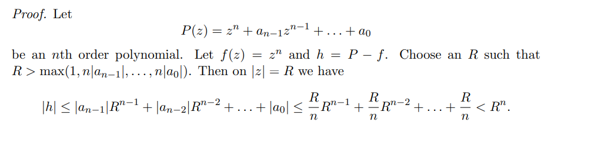

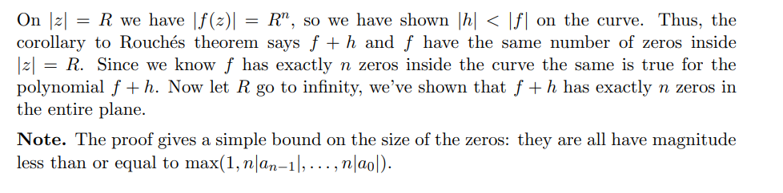

- Let $P(z) = a_nz^n + \cdots + a_0$
- Set $f(z) = a_n z^n$ and $g(z) = P(z) - f(z) = a_{n-1}z^{n-1} + \cdots + a_0$, so $f+g = P$.
- Choose $R > \max\qty{ { {\left\lvert {a_{n-1}} \right\rvert} + \cdots + {\left\lvert {a_0} \right\rvert} \over {\left\lvert {a_n} \right\rvert} }, 1}$, then

$$\begin{align*} |g(z)| &\coloneqq|a_{n-1}z^{n-1} + \cdots + a_1 z + a_0 | \\ &\leq |a_{n-1}z^{n-1}| + \cdots + |a_1 z| + |a_0 | \quad\text{by the triangle inequality} \\ &= |a_{n-1}|\cdot |z^{n-1}| + \cdots + |a_1|\cdot| z| + |a_0 | \\ &= |a_{n-1}|\cdot R^{n-1} + \cdots + |a_1| R + |a_0 | \\ &\leq |a_{n-1}|\cdot R^{n-1}+|a_{n-2}|\cdot R^{n-1} + \cdots + |a_1| \cdot R^{n-1} + |a_0 |\cdot R^{n-1} \quad\text{since } R>1 \implies R^{a+b} \geq R^a \\ &= R^{n-1} \left( |a_{n-1}| + |a_{n-2}| + \cdots + |a_1| + |a_0| \right) \\ &\leq R^{n-1} \left( |a_n|\cdot R \right) \quad\text{by choice of } R \\ &= R^{n} |a_n| \\ &= |a_n z^n| \\ &\coloneqq|f(z)| \end{align*}$$

- Then $a_n z^n$ has $n$ zeros in ${\left\lvert {z} \right\rvert} < R$, so $f+g$ also has $n$ zeros.

### 13.0.3 Liouville’s Theorem

**(Click to expand proof)**

- Suppose $p$ is nonconstant and has no roots, then ${1\over p}$ is entire. We will show it is also bounded and thus constant, a contradiction.
- Write $p(z) = z^n \left(a_n + \frac{a_{n-1}}{z}+\dots+\frac{a_{0}}{z^{n}}\right)$
- Outside a disc:
  - Note that $p(z) \overset{z\to \infty }\to \infty$. so there exists an $R$ large enough such that ${\left\lvert {p(z)} \right\rvert} \geq {1\over A}$ for any fixed chosen constant $A$.
  - Then ${\left\lvert { 1/p(z)} \right\rvert} \leq A$ outside of ${\left\lvert {z} \right\rvert} >R$, i.e. $1/p(z)$ is bounded there.
- Inside a disc:
  - $p$ is continuous with no roots and thus must be bounded below on ${\left\lvert {z} \right\rvert} < R$.
  - $p$ is entire and thus continuous, and since $\mkern 1.5mu\overline{\mkern-1.5muD\mkern-1.5mu}\mkern 1.5mu_r(0)$ is a compact set, $p$ achieves a min $A$ there
  - Set $C \mathrel{\vcenter{:}}=\min(A, B)$, then ${\left\lvert {p(z)} \right\rvert} \geq C$ on all of ${\mathbb{C}}$ and thus ${\left\lvert {1/p(z)} \right\rvert} \leq C$ everywhere.
  - So $1/p(z)$ is bounded an entire and thus constant by Liouville’s theorem – but this forces $p$ to be constant. $\contradiction$

### 13.0.4 Open Mapping Theorem

**(Click to expand proof)**

- $p$ induces a continuous map ${\mathbb{CP}}^1 \to {\mathbb{CP}}^1$
- The continuous image of compact space is compact;
- Since the codomain is Hausdorff space, the image is closed.
- $p$ is holomorphic and non-constant, so by the Open Mapping Theorem, the image is open.
- Thus the image is clopen in ${\mathbb{CP}}^1$.
- The image is nonempty, since $p(1) = \sum a_i \in {\mathbb{C}}$
- ${\mathbb{CP}}^1$ is connected
- But the only nonempty clopen subset of a connected space is the entire space.
- So $p$ is surjective, and $p^{-1}(0)$ is nonempty.
- So $p$ has a root.

### 13.0.5 Generalized Liouville

If $X$ is a compact complex manifold, any holomorphic $f:X\to {\mathbb{C}}$ is constant.

If $f:X\to Y$ is a nonconstant holomorphic map between Riemann surfaces with $X$ compact, then

- $f$ must be surjective,
- $Y$ must be compact,
- $f^{-1}(q)$ is finite for all $q\in Y$,
- The branch and ramification loci consist of finitely many points.

**(Click to expand proof)**

Given a nonconstant $p\in {\mathbb{C}}[x]$, regard it as a function $p: {\mathbb{P}}^1({\mathbb{C}}) \to {\mathbb{P}}^1({\mathbb{C}})$ by extending so that $p(\infty) = \infty$. Since $p$ is nonconstant, by the lemma $p$ is surjective, so there exists some $x\neq \infty$ in ${\mathbb{P}}^1({\mathbb{C}})$ with $p(x) = 0$.

# 14 Appendix

$$\begin{align*}
\Gamma(z) = \int_0^\infty t^{z-1}e^{-t} \,dt
.\end{align*}$$

Some interesting properties of $\Gamma$: $\Gamma(z+1) = z\Gamma(z)$ and has simple poles at $z=0,-1,-2,\cdots$ with residues $\mathop{\mathrm{Res}}_{z=-m} \Gamma(z) = (-1)^m/m!$. There is also a factorization
$$\begin{align*}
\Gamma(z) = {1 \over ze^{\gamma z} \prod_{n=1}^\infty \qty{1 + {z\over n}}e^{-z\over n} }
\end{align*}
where \(\gamma \mathrel{\vcenter{:}}=\lim_{N\to\infty } \sum_{n=1^N} {1\over n} - \log(N)$$

$$\begin{align*}
\Gamma(z) \Gamma(1-z) = {\pi \over \sin(\pi z)}
,\end{align*}
which yields a product factorization for \(\sin(\pi z)\).$$

${\mathcal{L}}(t^{z-1}, s=1) = \Gamma(z)$ and ${\mathcal{L}}(t^n, s=1) = \Gamma(n+1)$.

Every Riemann surface $S$ is the quotient of a free proper holomorphic action of a group $G$ on the universal cover $\tilde S$ of $S$, so $S\cong \tilde S/G$ is a biholomorphism. Moreover, $\tilde S$ is biholomorphic to either

- ${\mathbb{CP}}^1$
- ${\mathbb{C}}$
- ${\mathbb{D}}$

## 14.1 Misc Basic Algebra

- Circle: $x^2 + y^2 = r^2$
- Ellipse: $\qty{\frac x a}^2 + \qty{\frac y b}^2 = 1$
- Hyperbola: $\qty{\frac x a}^2 - \qty{\frac y b}^2 = 1$
  - Rectangular Hyperbola: $xy = \frac{c^2}{2}$.
- Parabola: $-4ax + y^2 = 0$.

Mnemonic: Write $f(x, y) = Ax^2 + Bxy + Cy^2 + \cdots$, then consider the discriminant $\Delta = B^2 - 4AC$:

- $\Delta < 0 \iff$ ellipse
  - $\Delta < 0$ and $A=C, B=0 \iff$ circle
- $\Delta = 0 \iff$ parabola
- $\Delta > 0 \iff$ hyperbola

$$\begin{align*}
x^2 - bx = (x - s)^2 - s^2 \quad\text{where} s = \frac{b}{2} \\
x^2 + bx = (x + s)^2 - s^2 \quad\text{where} s = \frac{b}{2}
.\end{align*}$$

The sum of the interior angles of an $n{\hbox{-}}$gon is $(n-2)\pi$, where each angle is $\frac{n-2}{n}\pi$.

Given a bounded piecewise continuous function $u:S^1\to {\mathbb{R}}$, is there a unique extension to a continuous harmonic function $\tilde u: {\mathbb{D}}\to {\mathbb{R}}$?

More generally, this is a boundary value problem for a region where the *values* of the function on the boundary are given. Compare to prescribing conditions on the normal vector on the boundary, which would be a Neumann BVP. Why these show up: a harmonic function on a simply connected region has a harmonic conjugate, and solutions of BVPs are always analytic functions with harmonic real/imaginary parts.

See section 27, example 1 in Brown and Churchill. On the strip $(x, y)\in (0, \pi) \times(0, \infty)$, set up the BVP for temperature on a thin plate with no sinks/sources:
$$\begin{align*}
\Delta T = 0 && T(0, y) = 0,\, T(\pi, y) = 0 \,\,\forall y \\ \\
T(x, 0) = \sin(x) && T(x, y) \overset{y\to\infty}\longrightarrow 0
.\end{align*}$$

Then the following function is harmonic on ${\mathbb{R}}^2$ and satisfies that Dirichlet problem:
$$\begin{align*}
T(x ,y) = e^{-y} \sin(x) = \Re(-ie^{iz}) = \Im(e^{iz})
.\end{align*}$$

Show that there is no continuous square root function defined on all of ${\mathbb{C}}$.

**(Click to expand solution)**

Suppose $f(z)^2 = z$. Then $f$ is a section to the covering map
$$\begin{align*}
p: {\mathbb{C}}^{\times}&\to {\mathbb{C}}^{\times}\\
z & \mapsto z^2
,\end{align*}
so \(p\circ f = \operatorname{id}\). Using \(\pi_1({\mathbb{C}}^{\times}) = {\mathbb{Z}}\), the induced maps are \(p_*(1) = 2\) and \(f_*(1) = n\) for some \(n\in {\mathbb{Z}}\). But then \(p_* \circ f_*\) is multiplication by \(2n\), contradicting \(p_* \circ f_* = \operatorname{id}\) by functoriality.$$

$$\begin{align*}
\widehat{f}(\xi) \mathrel{\vcenter{:}}={\mathcal{L}}(f, i\xi) \mathrel{\vcenter{:}}=\int_{\mathbb{R}}f(x) e^{-i\xi x} \,dx
.\end{align*}$$

Basics

- Show that ${1\over z} \sum_{k=1}^\infty {z^k \over k}$ converges on $S^1 \setminus\left\{{1}\right\}$ using summation by parts.
- Show that any power series is continuous on its domain of convergence.
- Show that a uniform limit of continuous functions is continuous.

- Show that if $f$ is holomorphic on ${\mathbb{D}}$ then $f$ has a power series expansion that converges uniformly on every compact $K\subset {\mathbb{D}}$.
- Show that any holomorphic function $f$ can be uniformly approximated by polynomials.
- Show that if $f$ is holomorphic on a connected region $\Omega$ and $f'\equiv 0$ on $\Omega$, then $f$ is constant on $\Omega$.
- Show that if ${\left\lvert {f} \right\rvert} = 0$ on ${{\partial}}\Omega$ then either $f$ is constant or $f$ has a zero in $\Omega$.
- Show that if $\left\{{f_n}\right\}$ is a sequence of holomorphic functions converging uniformly to a function $f$ on every compact subset of $\Omega$, then $f$ is holomorphic on $\Omega$ and $\left\{{f_n'}\right\}$ converges uniformly to $f'$ on every such compact subset.
- Show that if each $f_n$ is holomorphic on $\Omega$ and $F \mathrel{\vcenter{:}}=\sum f_n$ converges uniformly on every compact subset of $\Omega$, then $F$ is holomorphic.
- Show that if $f$ is once complex differentiable at each point of $\Omega$, then $f$ is holomorphic.

# 15 Bibliography